# BUS 317 - Final Project

Bridget Washington

2021-04-15

## Load Packages

```r
library(tidyverse)
library(RMySQL)
library(lubridate)
library(tidymodels)
library(kknn)
library(ggmap)
library(maps)
library(gridExtra)
library(gmodels)
```

# Part 1 - Office Express

## Database Connection

```r
db = dbConnect(MySQL(),
     user = 'ofx_user',
     password = 'TestyTester#2021',
     dbname = 'ofx',
     host = 'ballenger.wlu.edu')
```

## Load Data

### Save Tables as CSV

```r
# Buyer
buy <- dbSendQuery(db, 'SELECT * FROM buyer')
buyer <- fetch(buy, n = -1)
write_csv(buyer, path = "data/buyer.csv")

buyer <- read_csv("data/buyer.csv")
buyer <- buyer %>%
  rename_with(tolower)

# Category
cat <- dbSendQuery(db, 'SELECT * FROM category')
category <- fetch(cat, n = -1)
write_csv(category, path = "data/category.csv")

category <- read_csv("data/category.csv")
category <- category %>%
  rename_with(tolower)

# Location
loc <- dbSendQuery(db, 'SELECT * FROM location')
location <- fetch(loc, n = -1)
write_csv(location, path = "data/location.csv")

location <- read_csv("data/location.csv")
location <- location %>%
  rename_with(tolower)

# Order Product
ord_prod <- dbSendQuery(db, 'SELECT * FROM order_product')
order_product <- fetch(ord_prod, n = -1)
write_csv(order_product, path = "data/order_product.csv")

order_product <- read_csv("data/order_product.csv")
order_product <- order_product %>%
  rename_with(tolower)

# Orders
ord <- dbSendQuery(db, 'SELECT * FROM orders')
orders <- fetch(ord, n = -1)
write_csv(orders, path = "data/orders.csv")

orders <- read_csv("data/orders.csv")
orders <- orders %>%
  rename_with(tolower)

# Product
prod <- dbSendQuery(db, 'SELECT * FROM product')
product <- fetch(prod, n = -1)
write_csv(product, path = "data/product.csv")

product <- read_csv("data/product.csv")
product <- product %>%
  rename_with(tolower)
```

## Geocoding Location Data

```r
# lon_lat <- location %>%
#   distinct(city, state) %>%
#   mutate(city_state = paste(city, state, sep = ", ")) %>%
#   mutate_geocode(city_state)
#
# lon_lat %>%
#   arrange(state, city) %>%
#   head(10)
#
# write_csv(lon_lat, path = "data/lon_lat.csv")
```

## Inspect Data

```r
inspect <- function(x){
  x %>%
    glimpse() %>%
    summary() %>%
    head(10)
}

inspect(buyer)
```

```
## Rows: 793
## Columns: 4
## $ buyer_id   <chr> "AA-10315", "AA-10375", "AA-10480", "AA-10645", "AB-10015",…
## $ last_name  <chr> "Avila", "Armold", "Allen", "Andreadi", "Bergman", "Bellava…
## $ first_name <chr> "Alex", "Allen", "Andrew", "Anna", "Aaron", "Adam", "Adrian…
## $ type       <chr> "Consumer", "Consumer", "Consumer", "Consumer", "Consumer",…
```

```
##    buyer_id          last_name          first_name            type
##  Length:793         Length:793         Length:793         Length:793
##  Class :character   Class :character   Class :character   Class :character
##  Mode  :character   Mode  :character   Mode  :character   Mode  :character
```

```r
inspect(category)
```

```
## Rows: 17
## Columns: 2
## $ sub_category <chr> "Accessories", "Appliances", "Art", "Binders", "Bookcases…
## $ category     <chr> "Technology", "Office Supplies", "Office Supplies", "Offi…
```

```
##  sub_category         category
##  Length:17          Length:17
##  Class :character   Class :character
##  Mode  :character   Mode  :character
```

```r
inspect(location)
```

```
## Rows: 631
## Columns: 4
## $ postal_code <chr> "01040", "01453", "01752", "01810", "01841", "01852", "019…
## $ city        <chr> "Holyoke", "Leominster", "Marlborough", "Andover", "Lawren…
## $ state       <chr> "Massachusetts", "Massachusetts", "Massachusetts", "Massac…
## $ region      <chr> "East", "East", "East", "East", "East", "East", "East", "E…
```

```
##  postal_code            city              state              region
##  Length:631         Length:631         Length:631         Length:631
##  Class :character   Class :character   Class :character   Class :character
##  Mode  :character   Mode  :character   Mode  :character   Mode  :character
```

```r
inspect(order_product)
```

```
## Rows: 9,986
## Columns: 6
## $ order_id              <chr> "CA-2011-100006", "CA-2011-100090", "CA-2011-100…
## $ product_id            <chr> "TEC-PH-10002075", "FUR-TA-10003715", "OFF-BI-10…
## $ quantity              <dbl> 3, 3, 6, 6, 1, 2, 3, 2, 3, 2, 3, 3, 6, 2, 4, 2, …
## $ unit_price            <dbl> 125.990, 167.496, 32.784, 15.176, 3.928, 1.184, …
## $ discount              <dbl> 0.0, 0.2, 0.2, 0.2, 0.2, 0.2, 0.2, 0.0, 0.3, 0.2…
## $ gross_profit_per_unit <dbl> 36.5371, -29.3118, 11.4744, 5.3116, 1.3257, 0.41…
```

```
##    order_id          product_id           quantity       unit_price
##  Length:9986        Length:9986        Min.   : 1.00   Min.   :   0.336
##  Class :character   Class :character   1st Qu.: 2.00   1st Qu.:   5.448
##  Mode  :character   Mode  :character   Median : 3.00   Median :  16.267
##                                        Mean   : 3.79   Mean   :  60.914
##                                        3rd Qu.: 5.00   3rd Qu.:  63.926
##                                        Max.   :14.00   Max.   :3773.080
##     discount      gross_profit_per_unit
##  Min.   :0.0000   Min.   :-1320.0000
##  1st Qu.:0.0000   1st Qu.:    0.7202
##  Median :0.2000   Median :    2.7626
##  Mean   :0.1563   Mean   :    7.7946
##  3rd Qu.:0.2000   3rd Qu.:    8.6900
##  Max.   :0.8000   Max.   : 1680.0000
```

```r
inspect(orders)
```

```
## Rows: 5,009
## Columns: 6
## $ order_id    <chr> "CA-2011-100006", "CA-2011-100090", "CA-2011-100293", "CA-…
## $ order_date  <date> 2011-09-07, 2011-07-08, 2011-03-14, 2011-01-29, 2011-04-0…
## $ ship_date   <date> 2011-09-13, 2011-07-12, 2011-03-18, 2011-02-04, 2011-04-1…
## $ ship_mode   <chr> "Standard Class", "Standard Class", "Standard Class", "Sta…
## $ buyer_id    <chr> "DK-13375", "EB-13705", "NF-18475", "JC-15340", "JM-15655"…
## $ postal_code <chr> "10024", "94122", "32216", "10024", "85301", "10035", "770…
```

```
##    order_id           order_date           ship_date
##  Length:5009        Min.   :2011-01-04   Min.   :2011-01-08
##  Class :character   1st Qu.:2012-05-31   1st Qu.:2012-06-03
##  Mode  :character   Median :2013-07-11   Median :2013-07-14
##                     Mean   :2013-05-08   Mean   :2013-05-12
##                     3rd Qu.:2014-05-20   3rd Qu.:2014-05-25
##                     Max.   :2014-12-31   Max.   :2015-01-06
##   ship_mode           buyer_id         postal_code
##  Length:5009        Length:5009        Length:5009
##  Class :character   Class :character   Class :character
##  Mode  :character   Mode  :character   Mode  :character
##
##
##
```

```r
inspect(product)
```

```
## Rows: 1,862
## Columns: 3
## $ product_id   <chr> "FUR-BO-10000112", "FUR-BO-10000330", "FUR-BO-10000362", …
## $ product_name <chr> "Bush Birmingham Collection Bookcase, Dark Cherry", "Saud…
## $ sub_category <chr> "Bookcases", "Bookcases", "Bookcases", "Bookcases", "Book…
```

```
##   product_id        product_name       sub_category
##  Length:1862        Length:1862        Length:1862
##  Class :character   Class :character   Class :character
##  Mode  :character   Mode  :character   Mode  :character
```

```r
# Check for NA's
check_na <- function(x){
  x %>%
    select(everything()) %>%
    summarise_all(funs(sum(is.na(.))))
}

check_na(buyer)
```

```
## # A tibble: 1 x 4
##   buyer_id last_name first_name  type
##      <int>     <int>      <int> <int>
## 1        0         1          0     0
```

```r
check_na(category)
```

```
## # A tibble: 1 x 2
##   sub_category category
##          <int>    <int>
## 1            0        0
```

```r
check_na(location)
```

```
## # A tibble: 1 x 4
##   postal_code  city state region
##         <int> <int> <int>  <int>
## 1           0     0     0      0
```

```r
check_na(order_product)
```

```
## # A tibble: 1 x 6
##   order_id product_id quantity unit_price discount gross_profit_per_unit
##      <int>      <int>    <int>      <int>    <int>                 <int>
## 1        0          0        0          0        0                     0
```

```r
check_na(orders)
```

```
## # A tibble: 1 x 6
##   order_id order_date ship_date ship_mode buyer_id postal_code
##      <int>      <int>     <int>     <int>    <int>       <int>
## 1        0          0         0         0        0           0
```

```r
check_na(product)
```

```
## # A tibble: 1 x 3
##   product_id product_name sub_category
##        <int>        <int>        <int>
## 1          0            0            0
```

```r
buyer %>%
  arrange(last_name) %>%
  tail(1)
```

```
## # A tibble: 1 x 4
##   buyer_id last_name first_name type
##   <chr>    <chr>     <chr>      <chr>
## 1 Co-12640 NA        Corey-Lock Consumer
```

# Exploratory Data Analysis

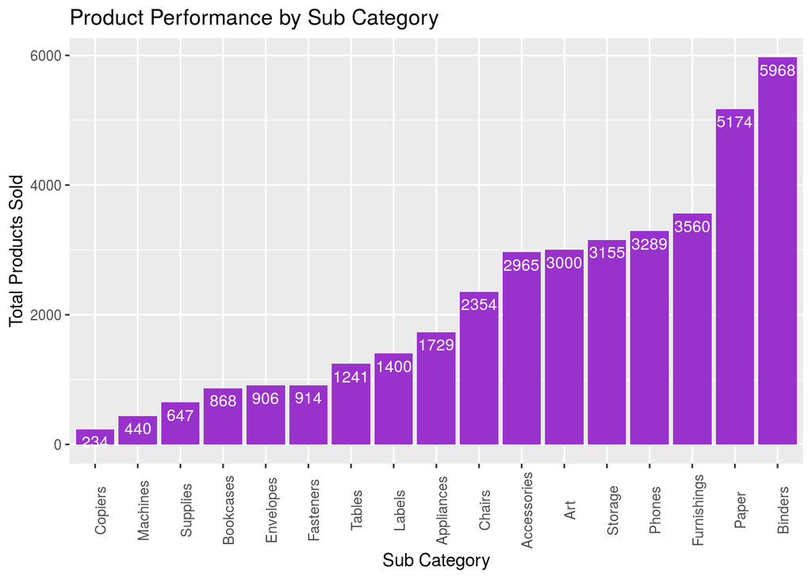

```r
product_category <- inner_join(product, category, by = "sub_category")
order_product_category <- inner_join(order_product, product_category, by = "product_id")

order_product_category %>%
  group_by(sub_category) %>%
  summarise(total_products =  sum(quantity)) %>%
  ungroup() %>%
  ggplot(aes(x = reorder(sub_category, total_products), y = total_products)) +
  geom_col(fill="darkorchid") +
  geom_text(aes(label = total_products), vjust = 1.6, color = "white", size = 3.5) +
  theme(axis.text.x = element_text(angle = 90)) +
  labs(title = "Product Performance by Sub Category",
       x = "Sub Category",
       y = "Total Products Sold")
```

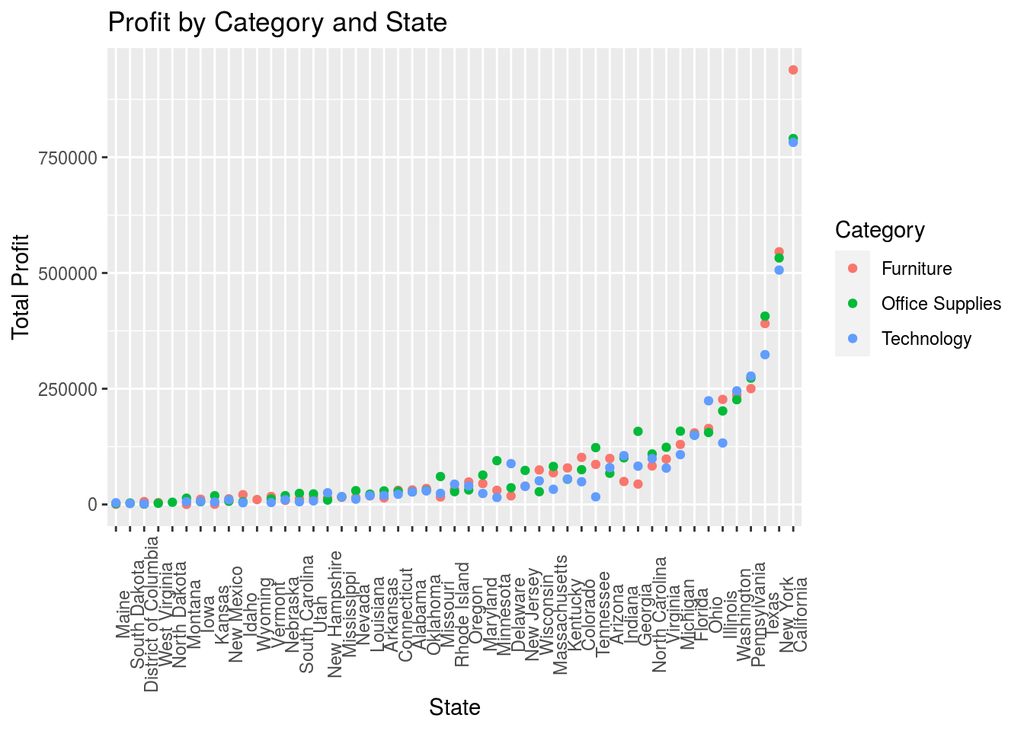

```r
# Profit Calculation
profit <- order_product_category %>%
  group_by(product_id) %>%
  summarise(product_profit = sum(unit_price * quantity * (1 - discount))) %>%
  ungroup()

ord_prod_profit <- inner_join(order_product_category, profit, by = "product_id")
ord_prod_profit2 <- inner_join(ord_prod_profit, orders, by = "order_id")
profit_loc <- inner_join(ord_prod_profit2, location, by = "postal_code")


profit_loc %>%
  group_by(state, category) %>%
  summarise(state_profit =  sum(product_profit)) %>%
  ungroup() %>%
  ggplot(aes(x = reorder(state, state_profit), y =  state_profit, color = category)) +
  geom_point() +
  theme(axis.text.x = element_text(angle = 90)) +
  labs(title = "Profit by Category and State",
       x = "State",
       y = "Total Profit",
       color = "Category")
```

#### Findings for Management (2)

California and New York are the states that bring in the highest amount of profit. Furniture is by far the most profitable category in California, and it is not the most profitable category in most other states. Perhaps we should start better marketing furniture to other states.

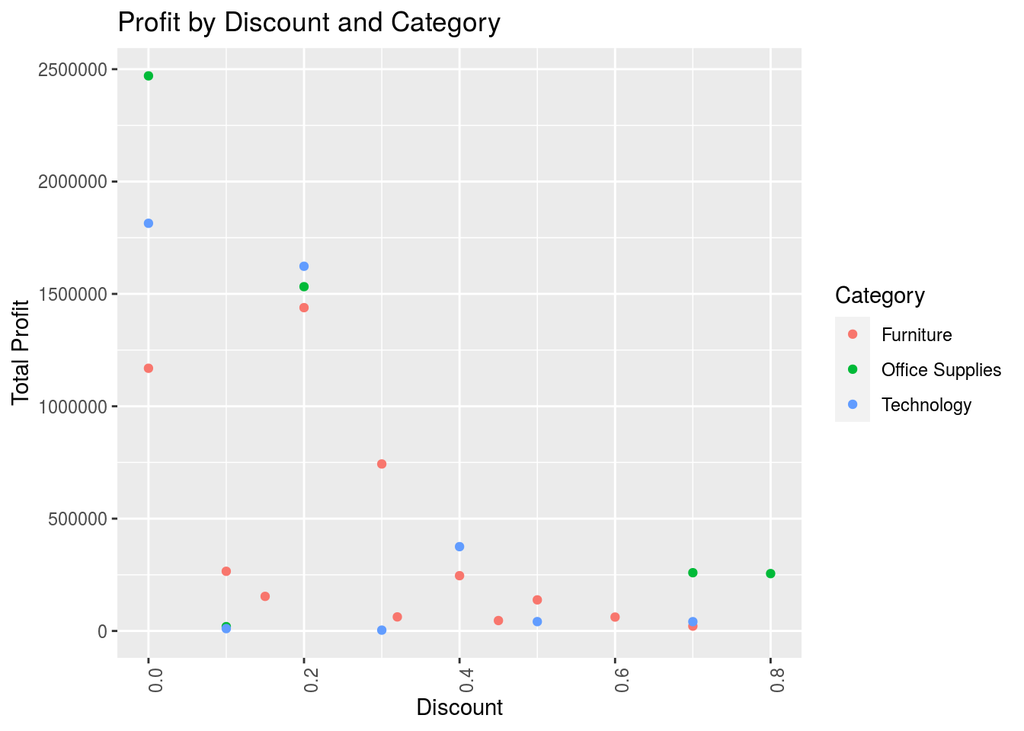

```r
profit_loc %>%
  group_by(discount, category) %>%
  summarise(disc_profit =  sum(product_profit)) %>%
  ungroup() %>%
  ggplot(aes(x = discount, y =  disc_profit, color = category)) +
  geom_point() +
  theme(axis.text.x = element_text(angle = 90)) +
  labs(title = "Profit by Discount and Category",
       x = "Discount",
       y = "Total Profit",
       color = "Category")
```

#### Findings for Management (3)

There does not appear to be a correlation between discounted items and higher profits. In fact, the company gets more profit from items that are not discounted. Perhaps we should consider restructuring our discount offerings.

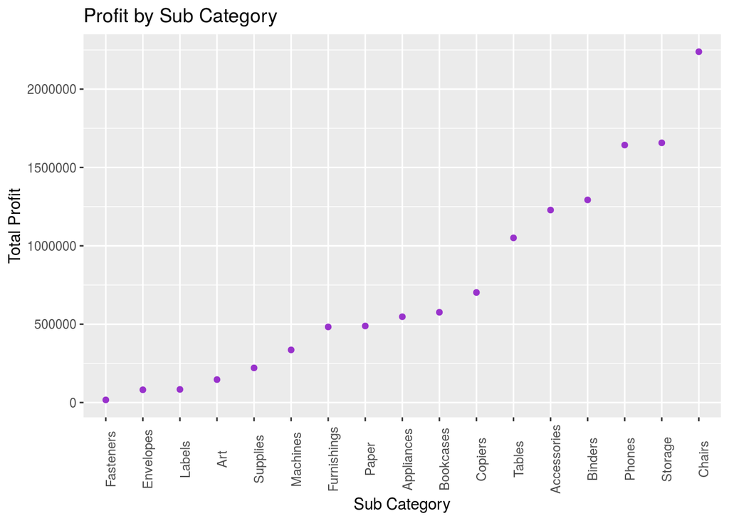

```r
 profit_loc %>%
  group_by(sub_category) %>%
  summarise(sub_cat_profit =  sum(product_profit)) %>%
  ungroup() %>%
  ggplot(aes(x = reorder(sub_category, sub_cat_profit), y =  sub_cat_profit)) +
  geom_point(color = "darkorchid") +
  theme(axis.text.x = element_text(angle = 90)) +
  labs(title = "Profit by Sub Category",
       x = "Sub Category",
       y = "Total Profit")
```

#### Findings for Management (4)

Fasteners, envelopes, and labels bring in the least amount of profit. Fasteners and envelopes are also in the list of underperforming products based on quanitity of orders. Perhaps we should consider halting our production of fasteners and envelopes and put more of our focus on furniture, which brings in more profit.

#### Findings for Management (5)

Binders are the best performing in terms of order quantity, but are fourth in terms of profit. Perhaps we should consider raising the price of binders slightly to increase profit for this item.

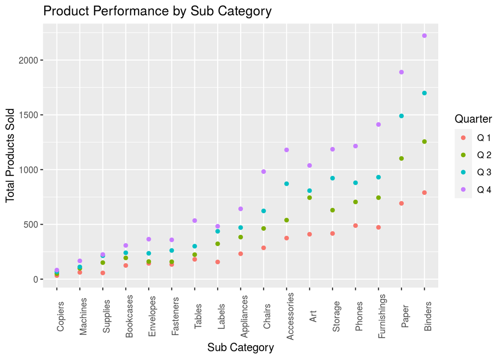

```r
ord_prod_season <- inner_join(order_product_category, orders, by = "order_id")
ord_prod_season <- ord_prod_season %>%
  mutate(qtr = paste("Q", quarter(order_date)))

ord_prod_season %>%
  group_by(sub_category, qtr) %>%
  summarise(total_products =  sum(quantity)) %>%
  ungroup() %>%
  ggplot(aes(x = reorder(sub_category, total_products), y = total_products, color = qtr)) +
  geom_point() +
  theme(axis.text.x = element_text(angle = 90)) +
  labs(title = "Product Performance by Sub Category",
       x = "Sub Category",
       y = "Total Products Sold",
       color = "Quarter")
```

#### Findings for Management (6)

Q1 is the worst performing quarter for all subcategories. Perhaps we should up our marketing efforts during this time of year.

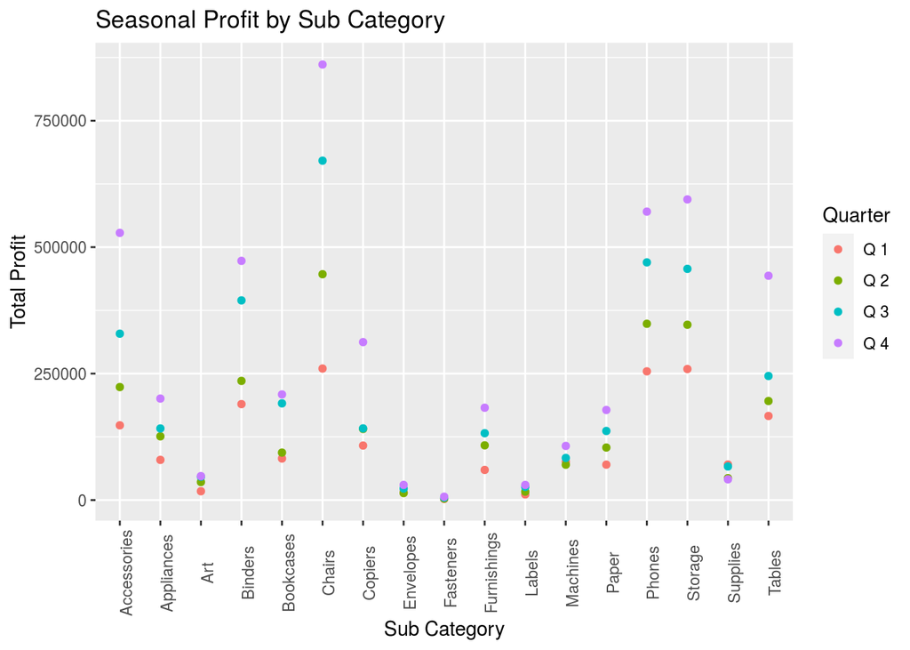

```r
profit_season <- inner_join(profit, ord_prod_season, by = "product_id")

profit_season %>%
  group_by(sub_category, qtr) %>%
  summarise(total_profit =  sum(product_profit)) %>%
  ungroup() %>%
  ggplot(aes(x = sub_category, y = total_profit, color = qtr)) +
  geom_point() +
  theme(axis.text.x = element_text(angle = 90)) +
  labs(title = "Seasonal Profit by Sub Category",
       x = "Sub Category",
       y = "Total Profit",
       color = "Quarter")
```

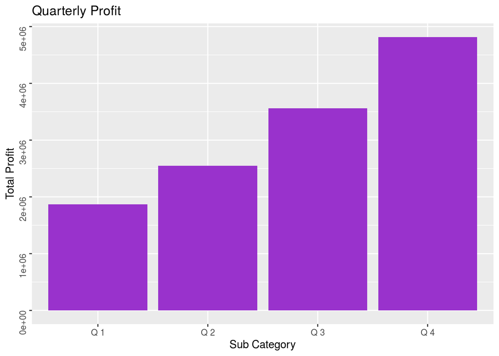

```r
profit_season %>%
  group_by(qtr) %>%
  summarise(total_profit =  sum(product_profit)) %>%
  ungroup() %>%
  ggplot(aes(x = qtr, y = total_profit)) +
  geom_col(fill = "darkorchid") +
  theme(axis.text.y = element_text(angle = 90)) +
  labs(title = "Quarterly Profit",
       x = "Sub Category",
       y = "Total Profit")
```

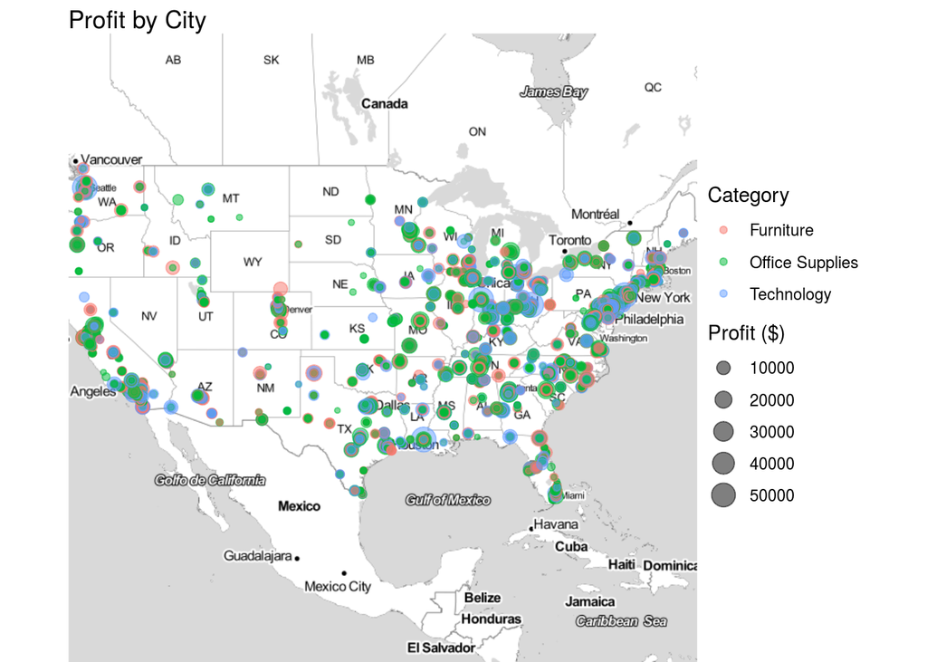

```r
lon_lat <- read_csv("data/lon_lat.csv")

lon_lat_products <- lon_lat %>%
  inner_join(profit_loc, by = "city") %>%
  select(-state.y)

get_map(location = 'usa', zoom = 4, source = "stamen", maptype = "toner-lite") %>%
  ggmap(base_layer = ggplot(lon_lat_products, aes(x = lon, y = lat, size = product_profit, color = category))) +
    geom_point(alpha = .5) +
    theme_void() +
    labs(title = "Profit by City") +
    guides(size = guide_legend("Profit ($)"),
           col = guide_legend("Category"))
```

#### Findings for Management (9)

The points on the map make it clear that there are not many orders occurring in the Midwest. We might consider further tapping into the Midwest market, as there is clearly an opportunity for growth. We could focus furniture and office supplies sales in this region, since there are obviously fewer corporate offices that need high tech tools in this region.

#### Findings for Management (10)

In general, I am surprised not to see more blue dots (technology) on the map. We seem to sell a lot of office supplies throughout the country, but I expected to see technology to be more prominent in the big cities.

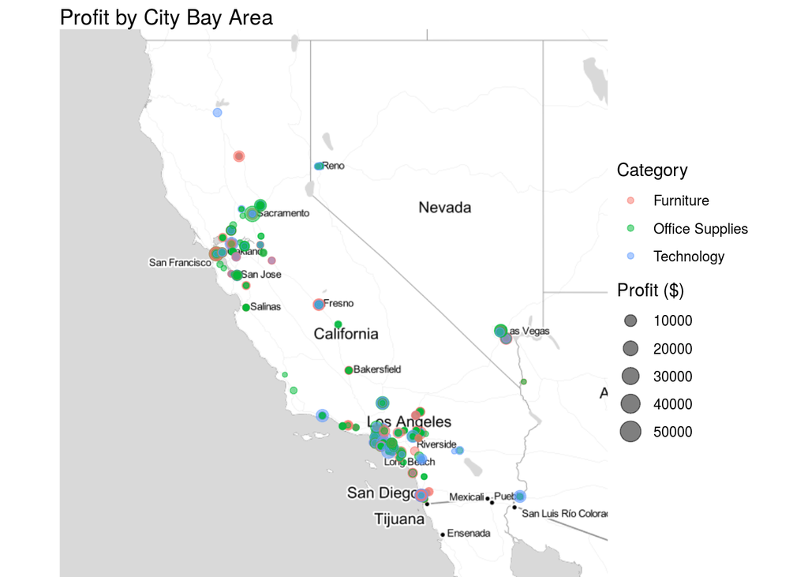

```r
get_map(location = 'California', zoom = 6, source = "stamen", maptype = "toner-lite") %>%
  ggmap(base_layer = ggplot(lon_lat_products, aes(x = lon, y = lat, size = product_profit, color = category))) +
    geom_point(alpha = .5) +
    theme_void() +
    labs(title = "Profit by City Bay Area") +
    guides(size = guide_legend("Profit ($)"),
           col = guide_legend("Category"))
```

#### Findings for Management (11)

California sales are concentrated in LA and SF. Perhaps we should expand into other cities.

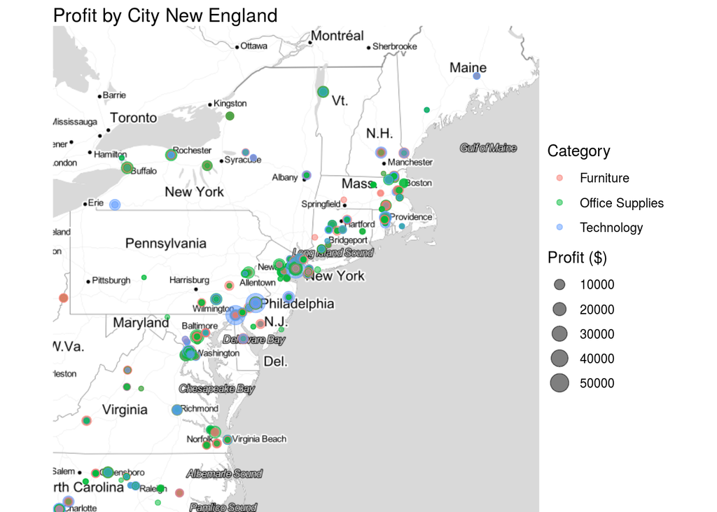

```r
get_map(location = 'New York', zoom = 6, source = "stamen", maptype = "toner-lite") %>%
  ggmap(base_layer = ggplot(lon_lat_products, aes(x = lon, y = lat, size = product_profit, color = category))) +
    geom_point(alpha = .5) +
    theme_void() +
    labs(title = "Profit by City New England") +
    guides(size = guide_legend("Profit ($)"),
           col = guide_legend("Category"))
```

#### Findings for Management (12)

Sales appear to be concentrated in big cities, but there is not much going on in cities like Pittsburgh. We should consider expanding into cities like this.

# Part 2 - k-NN Regression Analysis – Bike Shares Redux

## Load Data

```r
bikes <- read_csv("data/bike_share_hourly.csv")
```

### Clean Data

```r
bikes <- bikes %>%
  rename(work_day = workingday,
    weather = weathersit,
    temp_norm = temp,
    feeling_temp_norm = atemp,
    humidity_norm = hum,
    wind_speed_norm = windspeed,
    bike_count = cnt)
```

### Inspect Data

```r
# Exploratory R Functions
bikes %>%
  head(10)
```

```
## # A tibble: 10 x 17
##    instant dteday     season    yr  mnth    hr holiday weekday work_day weather
##      <dbl> <date>      <dbl> <dbl> <dbl> <dbl>   <dbl>   <dbl>    <dbl>   <dbl>
##  1       1 2011-01-01      1     0     1     0       0       6        0       1
##  2       2 2011-01-01      1     0     1     1       0       6        0       1
##  3       3 2011-01-01      1     0     1     2       0       6        0       1
##  4       4 2011-01-01      1     0     1     3       0       6        0       1
##  5       5 2011-01-01      1     0     1     4       0       6        0       1
##  6       6 2011-01-01      1     0     1     5       0       6        0       2
##  7       7 2011-01-01      1     0     1     6       0       6        0       1
##  8       8 2011-01-01      1     0     1     7       0       6        0       1
##  9       9 2011-01-01      1     0     1     8       0       6        0       1
## 10      10 2011-01-01      1     0     1     9       0       6        0       1
## # … with 7 more variables: temp_norm <dbl>, feeling_temp_norm <dbl>,
## #   humidity_norm <dbl>, wind_speed_norm <dbl>, casual <dbl>, registered <dbl>,
## #   bike_count <dbl>
```

```r
bikes %>%
  glimpse()
```

```
## Rows: 17,379
## Columns: 17
## $ instant           <dbl> 1, 2, 3, 4, 5, 6, 7, 8, 9, 10, 11, 12, 13, 14, 15, 1…
## $ dteday            <date> 2011-01-01, 2011-01-01, 2011-01-01, 2011-01-01, 201…
## $ season            <dbl> 1, 1, 1, 1, 1, 1, 1, 1, 1, 1, 1, 1, 1, 1, 1, 1, 1, 1…
## $ yr                <dbl> 0, 0, 0, 0, 0, 0, 0, 0, 0, 0, 0, 0, 0, 0, 0, 0, 0, 0…
## $ mnth              <dbl> 1, 1, 1, 1, 1, 1, 1, 1, 1, 1, 1, 1, 1, 1, 1, 1, 1, 1…
## $ hr                <dbl> 0, 1, 2, 3, 4, 5, 6, 7, 8, 9, 10, 11, 12, 13, 14, 15…
## $ holiday           <dbl> 0, 0, 0, 0, 0, 0, 0, 0, 0, 0, 0, 0, 0, 0, 0, 0, 0, 0…
## $ weekday           <dbl> 6, 6, 6, 6, 6, 6, 6, 6, 6, 6, 6, 6, 6, 6, 6, 6, 6, 6…
## $ work_day          <dbl> 0, 0, 0, 0, 0, 0, 0, 0, 0, 0, 0, 0, 0, 0, 0, 0, 0, 0…
## $ weather           <dbl> 1, 1, 1, 1, 1, 2, 1, 1, 1, 1, 1, 1, 1, 2, 2, 2, 2, 2…
## $ temp_norm         <dbl> 0.24, 0.22, 0.22, 0.24, 0.24, 0.24, 0.22, 0.20, 0.24…
## $ feeling_temp_norm <dbl> 0.2879, 0.2727, 0.2727, 0.2879, 0.2879, 0.2576, 0.27…
## $ humidity_norm     <dbl> 0.81, 0.80, 0.80, 0.75, 0.75, 0.75, 0.80, 0.86, 0.75…
## $ wind_speed_norm   <dbl> 0.0000, 0.0000, 0.0000, 0.0000, 0.0000, 0.0896, 0.00…
## $ casual            <dbl> 3, 8, 5, 3, 0, 0, 2, 1, 1, 8, 12, 26, 29, 47, 35, 40…
## $ registered        <dbl> 13, 32, 27, 10, 1, 1, 0, 2, 7, 6, 24, 30, 55, 47, 71…
## $ bike_count        <dbl> 16, 40, 32, 13, 1, 1, 2, 3, 8, 14, 36, 56, 84, 94, 1…
```

```r
bikes %>%
  summary()
```

```
##     instant          dteday               season            yr
##  Min.   :    1   Min.   :2011-01-01   Min.   :1.000   Min.   :0.0000
##  1st Qu.: 4346   1st Qu.:2011-07-04   1st Qu.:2.000   1st Qu.:0.0000
##  Median : 8690   Median :2012-01-02   Median :3.000   Median :1.0000
##  Mean   : 8690   Mean   :2012-01-02   Mean   :2.502   Mean   :0.5026
##  3rd Qu.:13034   3rd Qu.:2012-07-02   3rd Qu.:3.000   3rd Qu.:1.0000
##  Max.   :17379   Max.   :2012-12-31   Max.   :4.000   Max.   :1.0000
##       mnth              hr           holiday           weekday
##  Min.   : 1.000   Min.   : 0.00   Min.   :0.00000   Min.   :0.000
##  1st Qu.: 4.000   1st Qu.: 6.00   1st Qu.:0.00000   1st Qu.:1.000
##  Median : 7.000   Median :12.00   Median :0.00000   Median :3.000
##  Mean   : 6.538   Mean   :11.55   Mean   :0.02877   Mean   :3.004
##  3rd Qu.:10.000   3rd Qu.:18.00   3rd Qu.:0.00000   3rd Qu.:5.000
##  Max.   :12.000   Max.   :23.00   Max.   :1.00000   Max.   :6.000
##     work_day         weather        temp_norm     feeling_temp_norm
##  Min.   :0.0000   Min.   :1.000   Min.   :0.020   Min.   :0.0000
##  1st Qu.:0.0000   1st Qu.:1.000   1st Qu.:0.340   1st Qu.:0.3333
##  Median :1.0000   Median :1.000   Median :0.500   Median :0.4848
##  Mean   :0.6827   Mean   :1.425   Mean   :0.497   Mean   :0.4758
##  3rd Qu.:1.0000   3rd Qu.:2.000   3rd Qu.:0.660   3rd Qu.:0.6212
##  Max.   :1.0000   Max.   :4.000   Max.   :1.000   Max.   :1.0000
##  humidity_norm    wind_speed_norm      casual         registered
##  Min.   :0.0000   Min.   :0.0000   Min.   :  0.00   Min.   :  0.0
##  1st Qu.:0.4800   1st Qu.:0.1045   1st Qu.:  4.00   1st Qu.: 34.0
##  Median :0.6300   Median :0.1940   Median : 17.00   Median :115.0
##  Mean   :0.6272   Mean   :0.1901   Mean   : 35.68   Mean   :153.8
##  3rd Qu.:0.7800   3rd Qu.:0.2537   3rd Qu.: 48.00   3rd Qu.:220.0
##  Max.   :1.0000   Max.   :0.8507   Max.   :367.00   Max.   :886.0
##    bike_count
##  Min.   :  1.0
##  1st Qu.: 40.0
##  Median :142.0
##  Mean   :189.5
##  3rd Qu.:281.0
##  Max.   :977.0
```

```r
# Count NA values
bikes %>%
  select(everything()) %>%
  summarise_all(funs(sum(is.na(.))))
```

```
## # A tibble: 1 x 17
##   instant dteday season    yr  mnth    hr holiday weekday work_day weather
##     <int>  <int>  <int> <int> <int> <int>   <int>   <int>    <int>   <int>
## 1       0      0      0     0     0     0       0       0        0       0
## # … with 7 more variables: temp_norm <int>, feeling_temp_norm <int>,
## #   humidity_norm <int>, wind_speed_norm <int>, casual <int>, registered <int>,
## #   bike_count <int>
```

### Factor Variables

```r
bikes <- bikes %>%
  mutate(season = factor(season, labels = c("Winter", "Spring", "Summer", "Fall"))) %>%
  mutate(season = fct_relevel(season, c("Spring", "Summer", "Fall", "Winter")))

bikes <- bikes %>%
  mutate(yr = factor(yr, labels = c("2011", "2012")))

bikes <- bikes %>%
  mutate(mnth = factor(mnth, labels = c("January", "February", "March", "April", "May", "June", "July", "August", "September", "October", "November", "December"))) %>%
  mutate(mnth = fct_relevel(mnth, c("January", "February", "March", "April", "May", "June", "July", "August", "September", "October", "November", "December")))

bikes <- bikes %>%
  mutate(holiday = factor(holiday, labels = c("No", "Yes")))

bikes <- bikes %>%
  mutate(weekday = factor(weekday, labels = c("Sunday", "Monday", "Tuesday", "Wednesday", "Thursday", "Friday", "Saturday"))) %>%
  mutate(weekday = fct_relevel(weekday, c("Sunday", "Monday", "Tuesday", "Wednesday", "Thursday", "Friday", "Saturday")))

bikes <- bikes %>%
  mutate(work_day = factor(work_day, labels = c("No", "Yes")))

bikes <- bikes %>%
  mutate(weather = factor(weather, labels = c("Clear", "Mist", "Light Precipitation", "Heavy Precipitation"))) %>%
  mutate(weather = fct_relevel(weather, c("Clear", "Mist", "Light Precipitation", "Heavy Precipitation")))

bikes <- bikes %>%
  mutate(
    time_of_day = case_when(
      hr >= 0 & hr <= 6  ~ "night",
      hr >= 7 & hr <= 12  ~ "morning",
      hr >= 13 & hr <= 18  ~ "afternoon",
      hr >= 19 & hr <= 23  ~ "evening"
    )
  )

bikes <- bikes %>%
  mutate(time_of_day = factor(time_of_day, labels = c("night", "morning", "afternoon", "evening"))) %>%
  mutate(time_of_day = fct_relevel(time_of_day, c("night", "morning", "afternoon", "evening")))
```

Note: I realize that my facor levels are off for time_of_day. I could not ficure out how to revel them to be correct. I tried ever order of releveling and nothing worked.

## Question 1

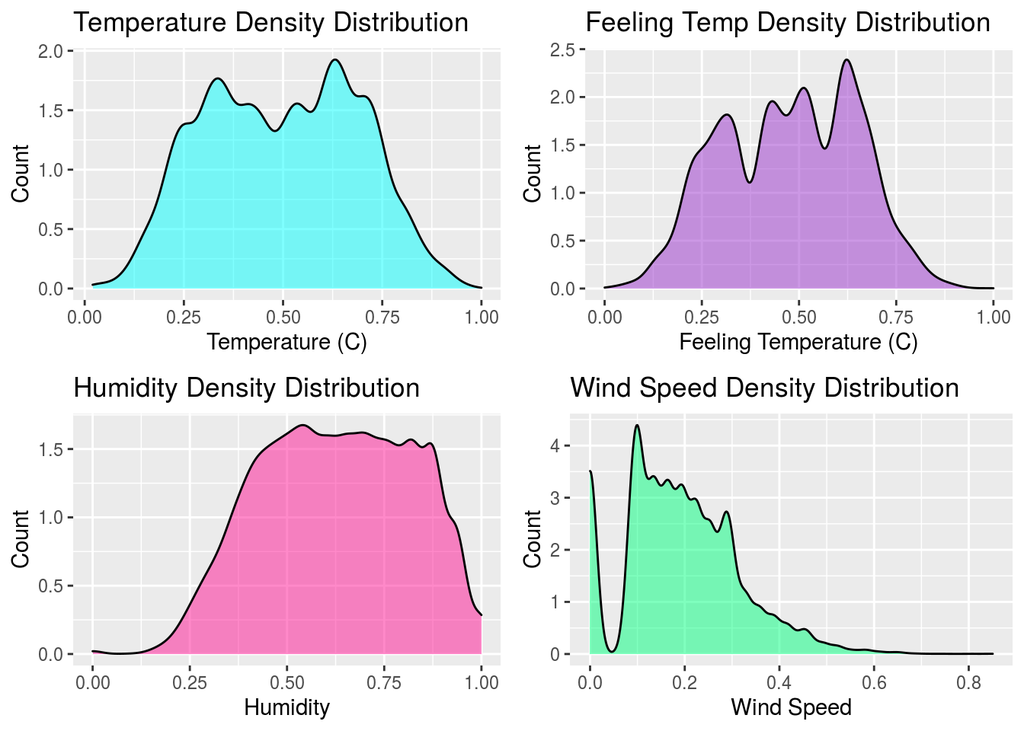

```r
temp_plot <- bikes %>%
  ggplot(aes(temp_norm)) +
  geom_density(fill = "cyan", alpha = 0.5) +
  labs(title = "Temperature Density Distribution",
       x = "Temperature (C)",
       y = "Count")

ftemp_plot <- bikes %>%
  ggplot(aes(feeling_temp_norm)) +
  geom_density(fill = "darkorchid", alpha = 0.5) +
  labs(title = "Feeling Temp Density Distribution",
       x = "Feeling Temperature (C)",
       y = "Count")

humidity_plot <- bikes %>%
  ggplot(aes(humidity_norm)) +
  geom_density(fill = "deeppink", alpha = 0.5) +
  labs(title = "Humidity Density Distribution",
       x = "Humidity",
       y = "Count")

wind_plot <- bikes %>%
  ggplot(aes(wind_speed_norm)) +
  geom_density(fill = "springgreen", alpha = 0.5) +
  labs(title = "Wind Speed Density Distribution",
       x = "Wind Speed",
       y = "Count")

grid.arrange(temp_plot, ftemp_plot, humidity_plot, wind_plot, ncol = 2, nrow = 2)
```

For the most part, it appears that these variables are adequately normalized for k-NN classification. I will not further normalize/standardize these variables.

## Question 2

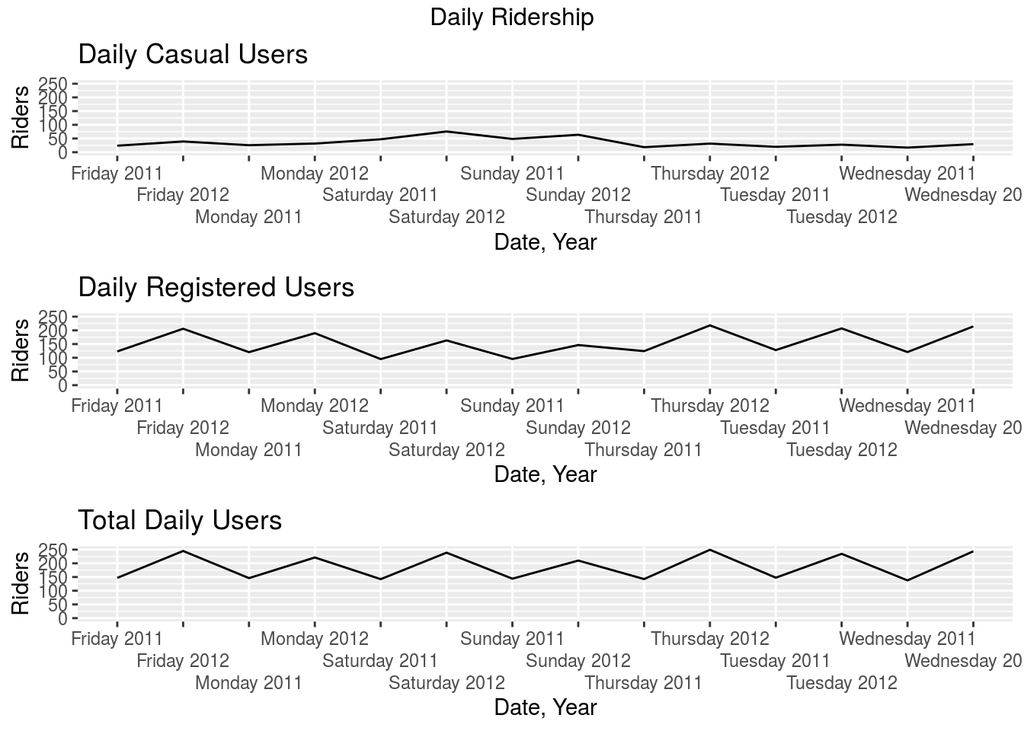

```r
bikes <- bikes %>%
  mutate(day_yr = paste(weekday, yr))

casual_line <- bikes %>%
  group_by(day_yr) %>%
  summarise(avg_casual_riders = mean(casual)) %>%
  ungroup() %>%
  ggplot(aes(x = day_yr, y = avg_casual_riders, group = 1)) +
  geom_line() +
  coord_cartesian(ylim = c(0, 250)) +
  scale_x_discrete(guide = guide_axis(n.dodge=3)) +
  labs(title = "Daily Casual Users",
       x = "Date, Year",
       y = "Riders")

registered_line <- bikes %>%
  group_by(day_yr) %>%
  summarise(avg_registered_riders = mean(registered)) %>%
  ungroup() %>%
  ggplot(aes(x = day_yr, y = avg_registered_riders, group = 1)) +
  geom_line() +
  coord_cartesian(ylim = c(0, 250)) +
  scale_x_discrete(guide = guide_axis(n.dodge=3)) +
  labs(title = "Daily Registered Users",
       x = "Date, Year",
       y = "Riders")

total_line <- bikes %>%
  group_by(day_yr) %>%
  summarise(avg_total_riders = mean(bike_count)) %>%
  ungroup() %>%
  ggplot(aes(x = day_yr, y = avg_total_riders, group = 1)) +
  geom_line() +
  coord_cartesian(ylim = c(0, 250)) +
  scale_x_discrete(guide = guide_axis(n.dodge=3)) +
  labs(title = "Total Daily Users",
       x = "Date, Year",
       y = "Riders")

grid.arrange(casual_line, registered_line, total_line, nrow = 3, ncol = 1, top = "Daily Ridership", heights = c(3, 3, 3))
```

Before I created these graphs, I created a variable “day_yr” that stores the average daily riders per week day, for both 2011 and 2012. On the graphs this is demonstrated by one point representing the 2011 average for that week day, and to its right, a point representing the same week day average in 2012.

Based on these graphs, it is obvious that the total number of riders per day is determined mostly by the registered users, not the casual users. The peaks and slopes of the “total users” graph is quite similar in shape to the “registered users” graph. Additionally, it is clear that 2012 was a much more successful year across the board, which is why I separated each week day into 2011 and 2012 values to graph separately. Management should take note of this fact and separate 2011 and 2012 data for future calculations.

## The Model

### Split Data

```r
# bikes_drop <- bikes %>%
#   select(-instant, -dteday, -yr, -hr, -registered, -casual, -day_yr)

set.seed(2021)

bikes_split <- initial_split(bikes, prop = .75)

bikes_train <- training(bikes_split)

bikes_test <- testing(bikes_split)

bikes_train %>%
  glimpse()
```

```
## Rows: 13,035
## Columns: 19
## $ instant           <dbl> 2, 3, 4, 5, 6, 7, 8, 9, 11, 14, 15, 16, 18, 19, 20, …
## $ dteday            <date> 2011-01-01, 2011-01-01, 2011-01-01, 2011-01-01, 201…
## $ season            <fct> Winter, Winter, Winter, Winter, Winter, Winter, Wint…
## $ yr                <fct> 2011, 2011, 2011, 2011, 2011, 2011, 2011, 2011, 2011…
## $ mnth              <fct> January, January, January, January, January, January…
## $ hr                <dbl> 1, 2, 3, 4, 5, 6, 7, 8, 10, 13, 14, 15, 17, 18, 19, …
## $ holiday           <fct> No, No, No, No, No, No, No, No, No, No, No, No, No, …
## $ weekday           <fct> Saturday, Saturday, Saturday, Saturday, Saturday, Sa…
## $ work_day          <fct> No, No, No, No, No, No, No, No, No, No, No, No, No, …
## $ weather           <fct> Clear, Clear, Clear, Clear, Mist, Clear, Clear, Clea…
## $ temp_norm         <dbl> 0.22, 0.22, 0.24, 0.24, 0.24, 0.22, 0.20, 0.24, 0.38…
## $ feeling_temp_norm <dbl> 0.2727, 0.2727, 0.2879, 0.2879, 0.2576, 0.2727, 0.25…
## $ humidity_norm     <dbl> 0.80, 0.80, 0.75, 0.75, 0.75, 0.80, 0.86, 0.75, 0.76…
## $ wind_speed_norm   <dbl> 0.0000, 0.0000, 0.0000, 0.0000, 0.0896, 0.0000, 0.00…
## $ casual            <dbl> 8, 5, 3, 0, 0, 2, 1, 1, 12, 47, 35, 40, 15, 9, 6, 11…
## $ registered        <dbl> 32, 27, 10, 1, 1, 0, 2, 7, 24, 47, 71, 70, 52, 26, 3…
## $ bike_count        <dbl> 40, 32, 13, 1, 1, 2, 3, 8, 36, 94, 106, 110, 67, 35,…
## $ time_of_day       <fct> evening, evening, evening, evening, evening, evening…
## $ day_yr            <chr> "Saturday 2011", "Saturday 2011", "Saturday 2011", "…
```

### Prep Data

```r
bikes_recipe <- recipe(time_of_day ~ ., data = bikes_train) %>%
  step_rm(instant, dteday, yr, hr, registered, casual, day_yr) %>%
  step_dummy(time_of_day, preserve = TRUE, one_hot = TRUE) %>%
  prep()
```

### Apply Recipe to Training Data

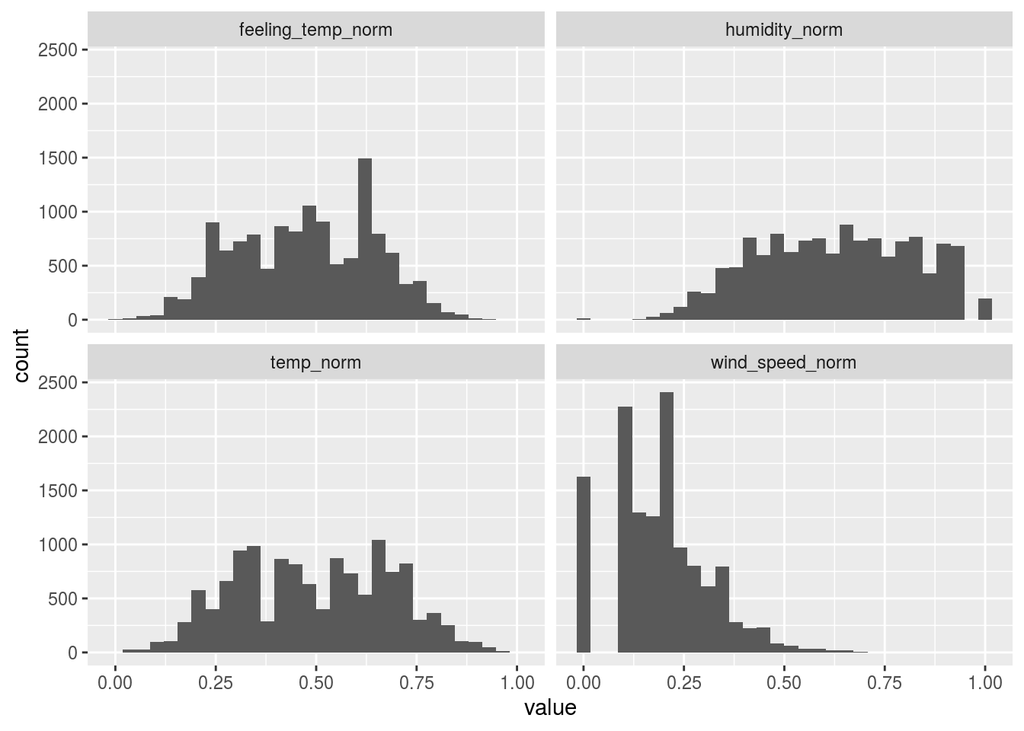

```r
bikes_juiced <- juice(bikes_recipe)

bikes_juiced %>%
  select(temp_norm, feeling_temp_norm, humidity_norm, wind_speed_norm, bike_count) %>%
  pivot_longer(-bike_count) %>%
    ggplot() +
    geom_histogram(aes(value, fill = bike_count)) +
    facet_wrap(~name)
```

### Bake Data

```r
bikes_test_baked <- bake(bikes_recipe, new_data = bikes_test)

bikes_train_baked <- bake(bikes_recipe, new_data = bikes_train)
```

### Test k Values

```r
for (i in seq(3, 19, 2)) {

  # Make a knn spec
  knn_spec <- nearest_neighbor(neighbor = i) %>%
    set_engine("kknn") %>%
    set_mode("classification")

  # Use the knn spec to fit the prepared training data
  knn_fit <- knn_spec %>%
    fit(time_of_day ~., data = bikes_juiced)

  # Evaluate the model with the training data
  train_knn_fit <-  knn_fit %>%
      predict(bikes_juiced) %>%
      bind_cols(bikes_juiced) %>%
      metrics(truth = time_of_day, estimate = .pred_class) %>%
      mutate(k = i)

  # Evaluate the model with the testing data
  test_knn_fit <- knn_fit %>%
      predict(bikes_test_baked) %>%
      bind_cols(bikes_test_baked) %>%
      metrics(truth = time_of_day, estimate = .pred_class) %>%
      mutate(k = i)

  # Create summary performance evaluation dataframes
  if (i == 3) {
  summary_train_knn_fit <- train_knn_fit
  summary_test_knn_fit <-  test_knn_fit
  } else {
  summary_train_knn_fit <- bind_rows(summary_train_knn_fit, train_knn_fit)
  summary_test_knn_fit <- bind_rows(summary_test_knn_fit, test_knn_fit)
  }

}

summary_train_knn_fit
```

```
## # A tibble: 18 x 4
##    .metric  .estimator .estimate     k
##    <chr>    <chr>          <dbl> <dbl>
##  1 accuracy multiclass         1     3
##  2 kap      multiclass         1     3
##  3 accuracy multiclass         1     5
##  4 kap      multiclass         1     5
##  5 accuracy multiclass         1     7
##  6 kap      multiclass         1     7
##  7 accuracy multiclass         1     9
##  8 kap      multiclass         1     9
##  9 accuracy multiclass         1    11
## 10 kap      multiclass         1    11
## 11 accuracy multiclass         1    13
## 12 kap      multiclass         1    13
## 13 accuracy multiclass         1    15
## 14 kap      multiclass         1    15
## 15 accuracy multiclass         1    17
## 16 kap      multiclass         1    17
## 17 accuracy multiclass         1    19
## 18 kap      multiclass         1    19
```

```r
summary_test_knn_fit
```

```
## # A tibble: 18 x 4
##    .metric  .estimator .estimate     k
##    <chr>    <chr>          <dbl> <dbl>
##  1 accuracy multiclass         1     3
##  2 kap      multiclass         1     3
##  3 accuracy multiclass         1     5
##  4 kap      multiclass         1     5
##  5 accuracy multiclass         1     7
##  6 kap      multiclass         1     7
##  7 accuracy multiclass         1     9
##  8 kap      multiclass         1     9
##  9 accuracy multiclass         1    11
## 10 kap      multiclass         1    11
## 11 accuracy multiclass         1    13
## 12 kap      multiclass         1    13
## 13 accuracy multiclass         1    15
## 14 kap      multiclass         1    15
## 15 accuracy multiclass         1    17
## 16 kap      multiclass         1    17
## 17 accuracy multiclass         1    19
## 18 kap      multiclass         1    19
```

Since we are working with a very large dataset, I did not use the sqrt of the number of rows, so that would be a number in the 100’s, which is much too large for k. So, I ran k values from 3 to 19. However, my k values all outputted an accuracy of 1, so there must be an error in my model. Since I am dealing with more than 2 classes, I needed to set the cutoff value properly, but I could not figure out how to do that. If my model had worked properly and the accuracy estimates were different numbers for each k value I tested, I would choose the lowest k value with the highest accuracy (but not equal to 1, as that suggests overfitting).

### 2012 Data

```r
bikes_2012 <- bikes %>%
  group_by(yr) %>%
  filter(yr == 2012)
```

### Split Data

```r
set.seed(2021)

bikes_split_2012 <- initial_split(bikes_2012, prop = .75)

bikes_train_2012 <- training(bikes_split_2012)

bikes_test_2012 <- testing(bikes_split_2012)

bikes_train_2012 %>%
  glimpse()
```

```
## Rows: 6,551
## Columns: 19
## Groups: yr [1]
## $ instant           <dbl> 8647, 8648, 8649, 8650, 8651, 8652, 8653, 8654, 8658…
## $ dteday            <date> 2012-01-01, 2012-01-01, 2012-01-01, 2012-01-01, 201…
## $ season            <fct> Winter, Winter, Winter, Winter, Winter, Winter, Wint…
## $ yr                <fct> 2012, 2012, 2012, 2012, 2012, 2012, 2012, 2012, 2012…
## $ mnth              <fct> January, January, January, January, January, January…
## $ hr                <dbl> 1, 2, 3, 4, 5, 6, 7, 8, 12, 13, 14, 15, 16, 17, 18, …
## $ holiday           <fct> No, No, No, No, No, No, No, No, No, No, No, No, No, …
## $ weekday           <fct> Sunday, Sunday, Sunday, Sunday, Sunday, Sunday, Sund…
## $ work_day          <fct> No, No, No, No, No, No, No, No, No, No, No, No, No, …
## $ weather           <fct> Clear, Clear, Clear, Clear, Clear, Clear, Clear, Cle…
## $ temp_norm         <dbl> 0.36, 0.32, 0.30, 0.28, 0.28, 0.26, 0.26, 0.26, 0.40…
## $ feeling_temp_norm <dbl> 0.3485, 0.3485, 0.3333, 0.3030, 0.2879, 0.2727, 0.25…
## $ humidity_norm     <dbl> 0.66, 0.76, 0.81, 0.81, 0.81, 0.93, 0.93, 0.87, 0.62…
## $ wind_speed_norm   <dbl> 0.1343, 0.0000, 0.0000, 0.0896, 0.1045, 0.1343, 0.16…
## $ casual            <dbl> 15, 16, 11, 0, 0, 1, 1, 4, 58, 82, 120, 101, 68, 36,…
## $ registered        <dbl> 78, 59, 41, 8, 5, 1, 6, 10, 143, 141, 147, 164, 147,…
## $ bike_count        <dbl> 93, 75, 52, 8, 5, 2, 7, 14, 201, 223, 267, 265, 215,…
## $ time_of_day       <fct> evening, evening, evening, evening, evening, evening…
## $ day_yr            <chr> "Sunday 2012", "Sunday 2012", "Sunday 2012", "Sunday…
```

### Prep 2012 Data

```r
bikes_recipe_2012 <- recipe(time_of_day ~ ., data = bikes_train_2012) %>%
  step_rm(instant, dteday, yr, hr, registered, casual, day_yr) %>%
  step_dummy(time_of_day, preserve = TRUE, one_hot = TRUE) %>%
  prep()
```

### Apply Recipe to Training Data

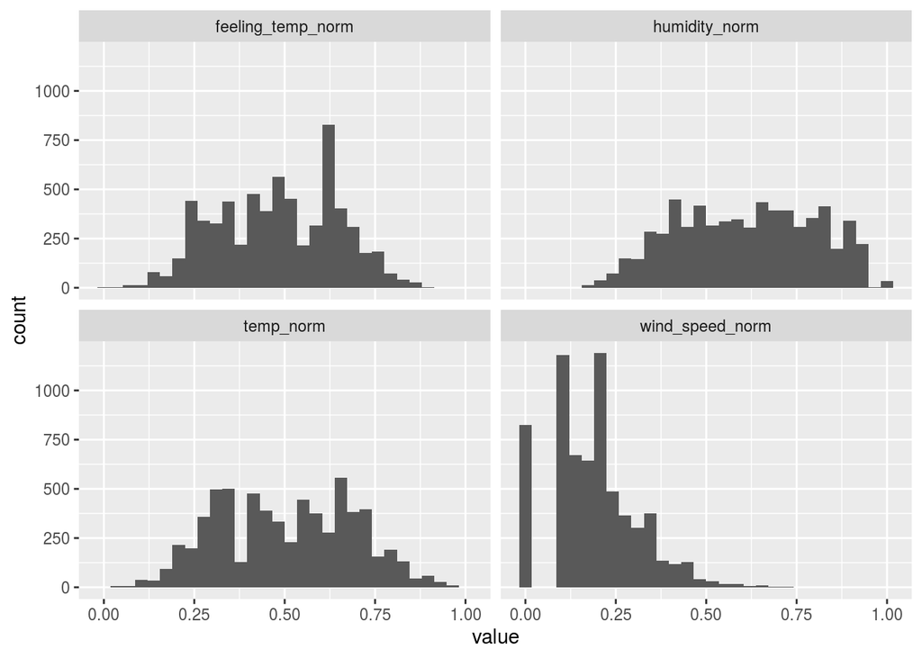

```r
bikes_juiced_2012 <- juice(bikes_recipe_2012)

bikes_juiced_2012 %>%
  select(temp_norm, feeling_temp_norm, humidity_norm, wind_speed_norm, bike_count) %>%
  pivot_longer(-bike_count) %>%
    ggplot() +
    geom_histogram(aes(value, fill = bike_count)) +
    facet_wrap(~name)
```

### Bake Data

```r
bikes_test_baked_2012 <- bake(bikes_recipe_2012, new_data = bikes_test_2012)

bikes_train_baked_2012 <- bake(bikes_recipe_2012, new_data = bikes_train_2012)
```

### Test k Values

```r
for (i in seq(3, 19, 2)) {

  # Make a knn spec
  knn_spec <- nearest_neighbor(neighbor = i) %>%
    set_engine("kknn") %>%
    set_mode("classification")

  # Use the knn spec to fit the prepared training data
  knn_fit <- knn_spec %>%
    fit(time_of_day ~., data = bikes_juiced_2012)

  # Evaluate the model with the training data
  train_knn_fit <-  knn_fit %>%
      predict(bikes_juiced_2012) %>%
      bind_cols(bikes_juiced_2012) %>%
      metrics(truth = time_of_day, estimate = .pred_class) %>%
      mutate(k = i)

  # Evaluate the model with the testing data
  test_knn_fit <- knn_fit %>%
      predict(bikes_test_baked_2012) %>%
      bind_cols(bikes_test_baked_2012) %>%
      metrics(truth = time_of_day, estimate = .pred_class) %>%
      mutate(k = i)

  # Create summary performance evaluation dataframes
  if (i == 3) {
  summary_train_knn_fit <- train_knn_fit
  summary_test_knn_fit <-  test_knn_fit
  } else {
  summary_train_knn_fit <- bind_rows(summary_train_knn_fit, train_knn_fit)
  summary_test_knn_fit <- bind_rows(summary_test_knn_fit, test_knn_fit)
  }

}

summary_train_knn_fit
```

```
## # A tibble: 18 x 4
##    .metric  .estimator .estimate     k
##    <chr>    <chr>          <dbl> <dbl>
##  1 accuracy multiclass         1     3
##  2 kap      multiclass         1     3
##  3 accuracy multiclass         1     5
##  4 kap      multiclass         1     5
##  5 accuracy multiclass         1     7
##  6 kap      multiclass         1     7
##  7 accuracy multiclass         1     9
##  8 kap      multiclass         1     9
##  9 accuracy multiclass         1    11
## 10 kap      multiclass         1    11
## 11 accuracy multiclass         1    13
## 12 kap      multiclass         1    13
## 13 accuracy multiclass         1    15
## 14 kap      multiclass         1    15
## 15 accuracy multiclass         1    17
## 16 kap      multiclass         1    17
## 17 accuracy multiclass         1    19
## 18 kap      multiclass         1    19
```

```r
summary_test_knn_fit
```

```
## # A tibble: 18 x 4
##    .metric  .estimator .estimate     k
##    <chr>    <chr>          <dbl> <dbl>
##  1 accuracy multiclass         1     3
##  2 kap      multiclass         1     3
##  3 accuracy multiclass         1     5
##  4 kap      multiclass         1     5
##  5 accuracy multiclass         1     7
##  6 kap      multiclass         1     7
##  7 accuracy multiclass         1     9
##  8 kap      multiclass         1     9
##  9 accuracy multiclass         1    11
## 10 kap      multiclass         1    11
## 11 accuracy multiclass         1    13
## 12 kap      multiclass         1    13
## 13 accuracy multiclass         1    15
## 14 kap      multiclass         1    15
## 15 accuracy multiclass         1    17
## 16 kap      multiclass         1    17
## 17 accuracy multiclass         1    19
## 18 kap      multiclass         1    19
```

(Same explanation from above) Since we are working with a very large dataset, I did not use the sqrt of the number of rows, so that would be a number in the 100’s, which is much too large for k. So, I ran k values from 3 to 19. However, my k values all outputted an accuracy of 1, so there must be an error in my model. Since I am dealing with more than 2 classes, I needed to set the cutoff value properly, but I could not figure out how to do that. If my model had worked properly and the accuracy estimates were different numbers for each k value I tested, I would choose the lowest k value with the highest accuracy (but not equal to 1, as that suggests overfitting).

## Regression

### Test k Values

```r
for (i in seq(3, 19, 2)) {

  # Make a knn spec
  knn_spec <- nearest_neighbor(neighbor = i) %>%
    set_engine("kknn") %>%
    set_mode("regression")

  # Use the knn spec to fit the prepared training data
  knn_fit <- knn_spec %>%
    fit(bike_count ~., data = bikes_juiced)

  # Evaluate the model with the training data
  train_knn_fit <-  knn_fit %>%
      predict(bikes_juiced) %>%
      bind_cols(bikes_juiced) %>%
      metrics(truth = bike_count, estimate = .pred) %>%
      mutate(k = i)

  # Evaluate the model with the testing data
  test_knn_fit <- knn_fit %>%
      predict(bikes_test_baked) %>%
      bind_cols(bikes_test_baked) %>%
      metrics(truth = bike_count, estimate = .pred) %>%
      mutate(k = i)

  # Create summary performance evaluation dataframes
  if (i == 3) {
  summary_train_knn_fit <- train_knn_fit
  summary_test_knn_fit <-  test_knn_fit
  } else {
  summary_train_knn_fit <- bind_rows(summary_train_knn_fit, train_knn_fit)
  summary_test_knn_fit <- bind_rows(summary_test_knn_fit, test_knn_fit)
  }

}

summary_train_knn_fit %>%
  filter(.metric %in% c("rmse", "rsq"))
```

```
## # A tibble: 18 x 4
##    .metric .estimator .estimate     k
##    <chr>   <chr>          <dbl> <dbl>
##  1 rmse    standard      44.0       3
##  2 rsq     standard       0.943     3
##  3 rmse    standard      61.2       5
##  4 rsq     standard       0.890     5
##  5 rmse    standard      71.3       7
##  6 rsq     standard       0.851     7
##  7 rmse    standard      77.9       9
##  8 rsq     standard       0.821     9
##  9 rmse    standard      82.6      11
## 10 rsq     standard       0.798    11
## 11 rmse    standard      86.2      13
## 12 rsq     standard       0.780    13
## 13 rmse    standard      89.0      15
## 14 rsq     standard       0.765    15
## 15 rmse    standard      91.3      17
## 16 rsq     standard       0.752    17
## 17 rmse    standard      93.1      19
## 18 rsq     standard       0.741    19
```

```r
summary_test_knn_fit %>%
  filter(.metric %in% c("rmse", "rsq"))
```

```
## # A tibble: 18 x 4
##    .metric .estimator .estimate     k
##    <chr>   <chr>          <dbl> <dbl>
##  1 rmse    standard     127.        3
##  2 rsq     standard       0.537     3
##  3 rmse    standard     122.        5
##  4 rsq     standard       0.559     5
##  5 rmse    standard     120.        7
##  6 rsq     standard       0.569     7
##  7 rmse    standard     119.        9
##  8 rsq     standard       0.574     9
##  9 rmse    standard     118.       11
## 10 rsq     standard       0.576    11
## 11 rmse    standard     117.       13
## 12 rsq     standard       0.579    13
## 13 rmse    standard     117.       15
## 14 rsq     standard       0.580    15
## 15 rmse    standard     117.       17
## 16 rsq     standard       0.582    17
## 17 rmse    standard     117.       19
## 18 rsq     standard       0.583    19
```

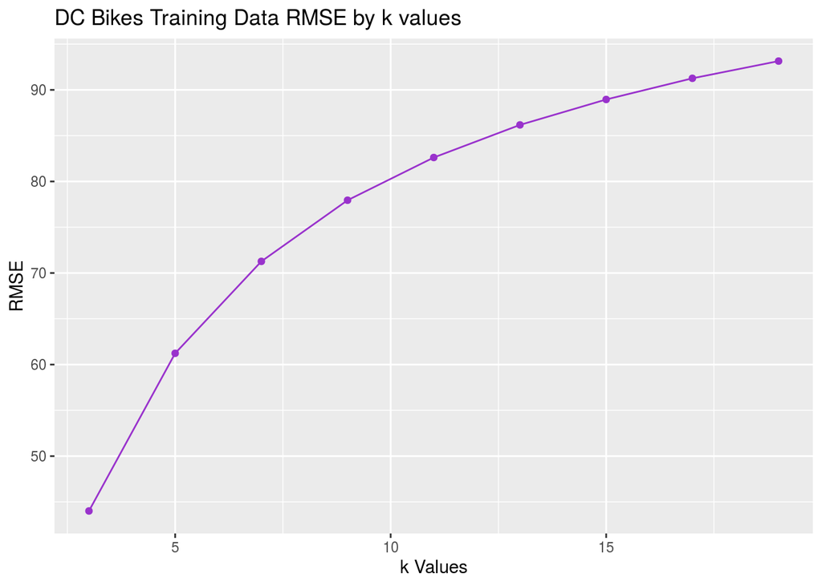

```r
summary_train_knn_fit %>%
  filter(.metric == "rmse") %>%
  ggplot(aes(x = k, y = .estimate)) +
  geom_point(color = "darkorchid") +
  geom_line(color = "darkorchid") +
  labs(title = "DC Bikes Training Data RMSE by k values",
       x = "k Values",
       y = "RMSE")
```

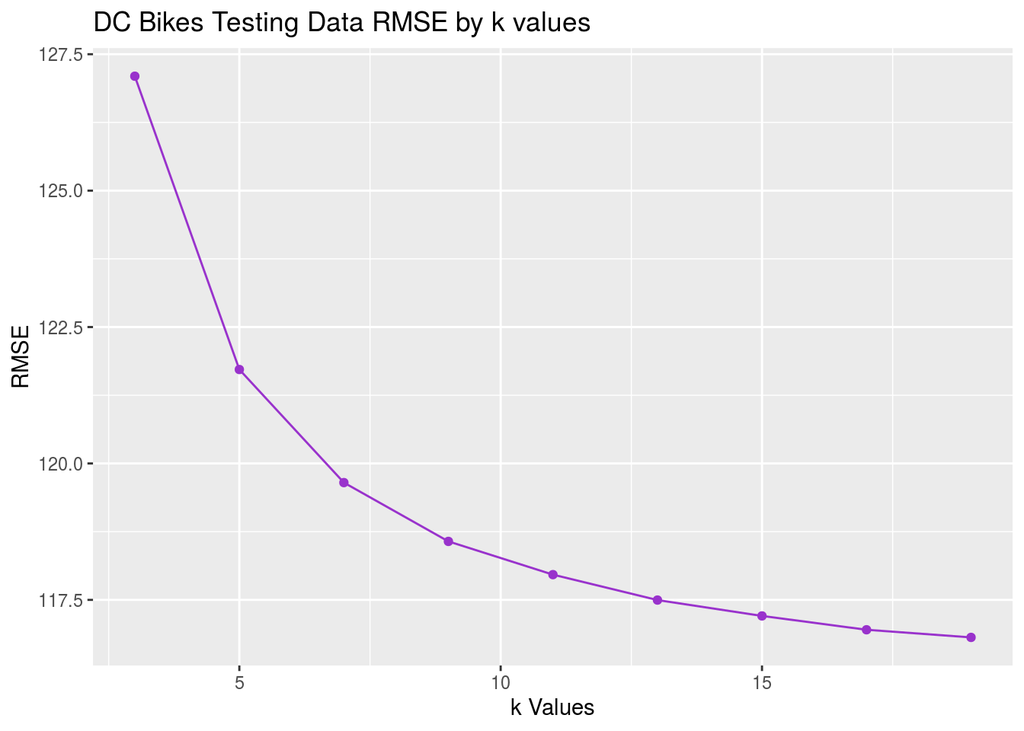

```r
summary_test_knn_fit %>%
  filter(.metric == "rmse") %>%
  ggplot(aes(x = k, y = .estimate)) +
  geom_point(color = "darkorchid") +
  geom_line(color = "darkorchid") +
  labs(title = "DC Bikes Testing Data RMSE by k values",
       x = "k Values",
       y = "RMSE")
```

### Use Final Model

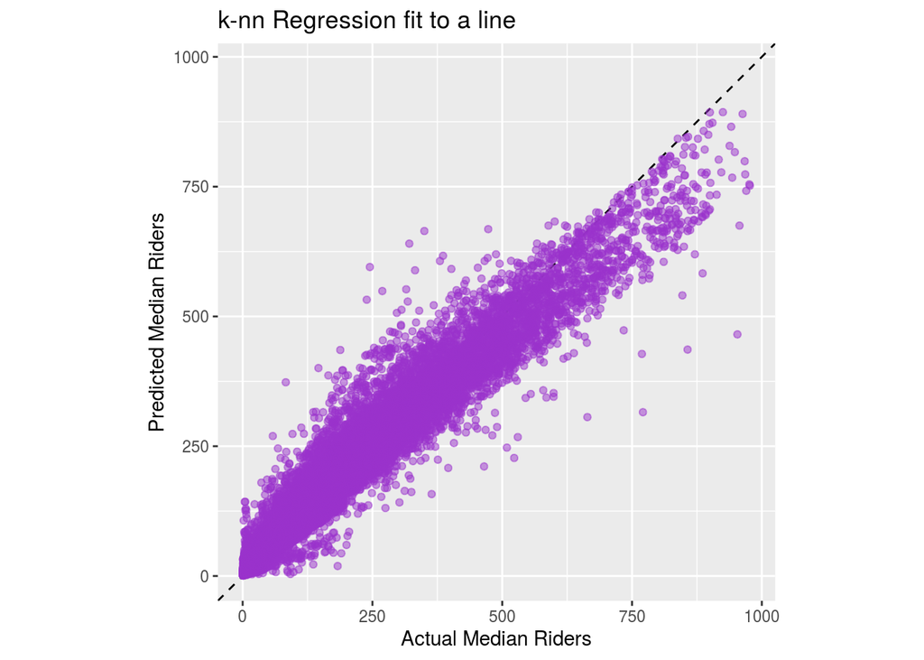

```r
bikes_baked <- bake(bikes_recipe, new_data = bikes)

knn_spec <- nearest_neighbor(neighbor = 3) %>%
  set_engine("kknn") %>%
  set_mode("regression")

final_knn_fit <- knn_spec %>%
  fit(bike_count ~., data = bikes_baked)

final_knn_fit %>%
  predict(bikes_baked) %>%
  bind_cols(bikes_baked) %>%
  select(bike_count, .pred) %>%
  ggplot(aes(x = bike_count, y = .pred)) +
  geom_abline(lty = 2) +
  geom_point(alpha = 0.5, color = "darkorchid") +
  labs(title = "k-nn Regression fit to a line",
       y = "Predicted Median Riders",
       x = "Actual Median Riders") +
  coord_obs_pred()
```

Since my model gave me problems with the accuracy estimates for the k values, I tested, I was unsure of the best k value to use for my model so I tested a few values as I created this regression. I ultimately chose to use a k value 3, since the points seemed to be better fitted to the line than with a k value of 5, which is the default k value. The regression here is linear. We can approximate what the output from the model should be by looking at the points nearest to the predictor line.

### Predict Ridership

```r
# bikes_baked <- bake(bikes_recipe, new_data = bikes)
#
# knn_spec <- nearest_neighbor(neighbor = 3) %>%
#   set_engine("kknn") %>%
#   set_mode("regression")
#
# final_knn_fit <- knn_spec %>%
#   fit(bike_count ~., data = bikes_baked)
#
# new_day <- tibble(season = "Winter",
#                   mnth = 2,
#                   hr = 6,
#                   holiday = "No",
#                   weekday = "Saturday",
#                   work_day = "No",
#                   weather = "Partly Cloudy",
#                   temp_norm = (5 + 8) /47,
#                   feeling_temp_norm = (3 + 16) / 66,
#                   humidity_norm = 60/100,
#                   wind_speed_norm = 0 / 67,
#                   time_of_day_night = 1,
#                   time_of_day_morning = 0,
#                   time_of_day_afternoon = 0,
#                   time_of_day_evening = 0,
#                   time_of_day = "night")
#
# # Predict classification of new data
# predict(final_knn_fit, new_data = new_day)
```

This code did not run properly, I kept getting error messages about the time_of_day variable. Since this code will not run properly, the document will not knit unless I comment it out, which is why I have done so. However, I kept in my attempt to predict the first day’s data so you can see what I was trying to do. I baked the data using my recipe with the total data and it produced a processed, prepped dataset with all the data in it. I then set my knn spec neighbor equal to 3. Then I did my final knn fit to bike_count and used the pre-processed data. I created a dataframe for my new day data, and used the predict function to predict the outcome variable.

# Part 3 - k-NN Classification Analysis – Customer Automobile Preferences

```r
auto_segments <- read_csv("data/auto_segments.csv")

auto_segments %>%
  head(10)
```

```
## # A tibble: 10 x 11
##        ID Gender Ever_Married   Age Graduated Profession    Work_Experience
##     <dbl> <chr>  <chr>        <dbl> <chr>     <chr>                   <dbl>
##  1 462809 Male   No              22 No        Healthcare                  1
##  2 462643 Female Yes             38 Yes       Engineer                   NA
##  3 466315 Female Yes             67 Yes       Engineer                    1
##  4 461735 Male   Yes             67 Yes       Lawyer                      0
##  5 462669 Female Yes             40 Yes       Entertainment              NA
##  6 461319 Male   Yes             56 No        Artist                      0
##  7 460156 Male   No              32 Yes       Healthcare                  1
##  8 464347 Female No              33 Yes       Healthcare                  1
##  9 465015 Female Yes             61 Yes       Engineer                    0
## 10 465176 Female Yes             55 Yes       Artist                      1
## # … with 4 more variables: Spending_Score <chr>, Family_Size <dbl>,
## #   Var_1 <chr>, Segmentation <chr>
```

```r
auto_segments %>%
  glimpse()
```

```
## Rows: 10,686
## Columns: 11
## $ ID              <dbl> 462809, 462643, 466315, 461735, 462669, 461319, 460156…
## $ Gender          <chr> "Male", "Female", "Female", "Male", "Female", "Male", …
## $ Ever_Married    <chr> "No", "Yes", "Yes", "Yes", "Yes", "Yes", "No", "No", "…
## $ Age             <dbl> 22, 38, 67, 67, 40, 56, 32, 33, 61, 55, 26, 19, 19, 70…
## $ Graduated       <chr> "No", "Yes", "Yes", "Yes", "Yes", "No", "Yes", "Yes", …
## $ Profession      <chr> "Healthcare", "Engineer", "Engineer", "Lawyer", "Enter…
## $ Work_Experience <dbl> 1, NA, 1, 0, NA, 0, 1, 1, 0, 1, 1, 4, 0, NA, 0, 1, 9, …
## $ Spending_Score  <chr> "Low", "Average", "Low", "High", "High", "Average", "L…
## $ Family_Size     <dbl> 4, 3, 1, 2, 6, 2, 3, 3, 3, 4, 3, 4, NA, 1, 1, 2, 5, 6,…
## $ Var_1           <chr> "Cat_4", "Cat_4", "Cat_6", "Cat_6", "Cat_6", "Cat_6", …
## $ Segmentation    <chr> "D", "A", "B", "B", "A", "C", "C", "D", "D", "C", "A",…
```

```r
auto_segments <- auto_segments %>%
  rename_with(tolower)

auto_segments %>%
    select(everything()) %>%
    summarise_all(funs(sum(is.na(.))))
```

```
## # A tibble: 1 x 11
##      id gender ever_married   age graduated profession work_experience
##   <int>  <int>        <int> <int>     <int>      <int>           <int>
## 1     0      0          190     0       102        161            1097
## # … with 4 more variables: spending_score <int>, family_size <int>,
## #   var_1 <int>, segmentation <int>
```

```r
auto_segments[!complete.cases(auto_segments),]
```

```
## # A tibble: 1,874 x 11
##        id gender ever_married   age graduated profession    work_experience
##     <dbl> <chr>  <chr>        <dbl> <chr>     <chr>                   <dbl>
##  1 462643 Female Yes             38 Yes       Engineer                   NA
##  2 462669 Female Yes             40 Yes       Entertainment              NA
##  3 461230 Female No              19 No        Executive                   0
##  4 459573 Male   Yes             70 No        Lawyer                     NA
##  5 461021 Female NA              58 No        Executive                   1
##  6 467010 Male   No              26 No        Homemaker                   9
##  7 467442 Male   Yes             56 Yes       Artist                     NA
##  8 466006 Female Yes             49 Yes       Artist                      1
##  9 463156 Female Yes             79 No        Lawyer                     NA
## 10 462384 Female No              29 Yes       Healthcare                 NA
## # … with 1,864 more rows, and 4 more variables: spending_score <chr>,
## #   family_size <dbl>, var_1 <chr>, segmentation <chr>
```

```r
auto_segments <- na.omit(auto_segments)
```

### Factor Data

```r
auto_segments <- auto_segments %>%
  mutate(gender = factor(gender, labels = c("Male", "Female"))) %>%
  mutate(gender = fct_relevel(gender, c("Male", "Female")))

auto_segments <- auto_segments %>%
  mutate(ever_married = factor(ever_married, labels = c("No", "Yes"))) %>%
  mutate(ever_married = fct_relevel(ever_married, c("No", "Yes")))

auto_segments <- auto_segments %>%
  mutate(graduated = factor(graduated, labels = c("No", "Yes"))) %>%
  mutate(graduated = fct_relevel(graduated, c("No", "Yes")))

auto_segments <- auto_segments %>%
  mutate(profession = factor(profession, labels = c("Artist", "Doctor", "Engineer", "Entertainment", "Executive", "Healthcare", "Homemaker", "Lawyer", "Marketing")))

auto_segments <- auto_segments %>%
  mutate(spending_score = factor(spending_score, labels = c("Low", "High", "Average"))) %>%
  mutate(spending_score = fct_relevel(spending_score, c("High", "Average", "Low")))

auto_segments <- auto_segments %>%
  mutate(segmentation = factor(segmentation, labels = c("D", "B", "C", "A"))) %>%
  mutate(segmentation = fct_relevel(segmentation, c("D", "C", "B", "A")))
```

## Crosstabs

```r
# Gender
gender_table <- table(auto_segments$segmentation, auto_segments$gender)
ftable(gender_table)
```

```
##    Male Female
##
## D  1056   1251
## C   976   1124
## B   916   1103
## A  1008   1378
```

```r
CrossTable(auto_segments$segmentation, auto_segments$gender)
```

```
##
##
##    Cell Contents
## |-------------------------|
## |                       N |
## | Chi-square contribution |
## |           N / Row Total |
## |           N / Col Total |
## |         N / Table Total |
## |-------------------------|
##
##
## Total Observations in Table:  8812
##
##
##                            | auto_segments$gender
## auto_segments$segmentation |      Male |    Female | Row Total |
## ---------------------------|-----------|-----------|-----------|
##                          D |      1056 |      1251 |      2307 |
##                            |     0.398 |     0.324 |           |
##                            |     0.458 |     0.542 |     0.262 |
##                            |     0.267 |     0.258 |           |
##                            |     0.120 |     0.142 |           |
## ---------------------------|-----------|-----------|-----------|
##                          C |       976 |      1124 |      2100 |
##                            |     1.172 |     0.955 |           |
##                            |     0.465 |     0.535 |     0.238 |
##                            |     0.247 |     0.231 |           |
##                            |     0.111 |     0.128 |           |
## ---------------------------|-----------|-----------|-----------|
##                          B |       916 |      1103 |      2019 |
##                            |     0.102 |     0.083 |           |
##                            |     0.454 |     0.546 |     0.229 |
##                            |     0.232 |     0.227 |           |
##                            |     0.104 |     0.125 |           |
## ---------------------------|-----------|-----------|-----------|
##                          A |      1008 |      1378 |      2386 |
##                            |     3.724 |     3.033 |           |
##                            |     0.422 |     0.578 |     0.271 |
##                            |     0.255 |     0.284 |           |
##                            |     0.114 |     0.156 |           |
## ---------------------------|-----------|-----------|-----------|
##               Column Total |      3956 |      4856 |      8812 |
##                            |     0.449 |     0.551 |           |
## ---------------------------|-----------|-----------|-----------|
##
##
```

```r
#Ever Married
married_table <- table(auto_segments$segmentation, auto_segments$ever_married)
ftable(married_table)
```

```
##      No  Yes
##
## D   969 1338
## C   444 1656
## B   573 1446
## A  1617  769
```

```r
CrossTable(auto_segments$segmentation, auto_segments$ever_married)
```

```
##
##
##    Cell Contents
## |-------------------------|
## |                       N |
## | Chi-square contribution |
## |           N / Row Total |
## |           N / Col Total |
## |         N / Table Total |
## |-------------------------|
##
##
## Total Observations in Table:  8812
##
##
##                            | auto_segments$ever_married
## auto_segments$segmentation |        No |       Yes | Row Total |
## ---------------------------|-----------|-----------|-----------|
##                          D |       969 |      1338 |      2307 |
##                            |     0.702 |     0.485 |           |
##                            |     0.420 |     0.580 |     0.262 |
##                            |     0.269 |     0.257 |           |
##                            |     0.110 |     0.152 |           |
## ---------------------------|-----------|-----------|-----------|
##                          C |       444 |      1656 |      2100 |
##                            |   200.228 |   138.495 |           |
##                            |     0.211 |     0.789 |     0.238 |
##                            |     0.123 |     0.318 |           |
##                            |     0.050 |     0.188 |           |
## ---------------------------|-----------|-----------|-----------|
##                          B |       573 |      1446 |      2019 |
##                            |    77.242 |    53.428 |           |
##                            |     0.284 |     0.716 |     0.229 |
##                            |     0.159 |     0.278 |           |
##                            |     0.065 |     0.164 |           |
## ---------------------------|-----------|-----------|-----------|
##                          A |      1617 |       769 |      2386 |
##                            |   421.728 |   291.704 |           |
##                            |     0.678 |     0.322 |     0.271 |
##                            |     0.449 |     0.148 |           |
##                            |     0.183 |     0.087 |           |
## ---------------------------|-----------|-----------|-----------|
##               Column Total |      3603 |      5209 |      8812 |
##                            |     0.409 |     0.591 |           |
## ---------------------------|-----------|-----------|-----------|
##
##
```

```r
# Age
age_table <- table(auto_segments$segmentation, auto_segments$age)
ftable(age_table)
```

```
##     18  19  20  21  22  23  25  26  27  28  29  30  31  32  33  35  36  37  38  39  40  41  42  43  45  46  47  48  49  50  51  52  53  55  56  57  58  59  60  61  62  63  65  66  67  68  69  70  71  72  73  74  75  76  77  78  79  80  81  82  83  84  85  86  87  88  89
##
## D    8  25  16   7  10   6  71  61  60  80  58  70  74  68  73 101  74  82  83  82  87  81  97  92  55  37  40  35  42  32  37  36  46  26  19  22  11  16  18  15  14  14  22  18  14  19  17  11  14  14  13   9   5  15  13   8   9   5  10  19  13  14  11  11  16  10  16
## C    5   9   4   7   6   9  29  23  37  33  26  24  29  26  41  52  55  58  51  48  40  56  68  43  58  72  72  70  69  78  73  69  59  39  42  42  37  40  48  41  35  39  25  30  15  24  28  26  23  22  26  10   7   6   8   5   9   5   7   4   9   2   5  13  11  10   8
## B   11   4   8   7   7  13  34  24  41  37  32  26  29  27  33  67  67  60  74  63  69  61  67  82  55  60  47  55  38  70  51  57  45  36  34  24  28  39  32  33  40  26  27  18  26  16  20  28  17  19  19  10   9   7   6   9   6   5  13   9  10  10   0   8   3   6   5
## A  113 107 110 103 119 110  97 117 107  94  85 107  89 109  92  45  40  49  40  39  51  33  44  33  18  27  18  23  23  21  15  11  23   4   8   6   6   9   6  15   5  12  10  12   8  11  11   8  10  10   9   5  11   4   8   5   9   8   7   7  10   8   9   6   4   8   5
```

```r
CrossTable(auto_segments$segmentation, auto_segments$age)
```

```
##
##
##    Cell Contents
## |-------------------------|
## |                       N |
## | Chi-square contribution |
## |           N / Row Total |
## |           N / Col Total |
## |         N / Table Total |
## |-------------------------|
##
##
## Total Observations in Table:  8812
##
##
##                            | auto_segments$age
## auto_segments$segmentation |        18 |        19 |        20 |        21 |        22 |        23 |        25 |        26 |        27 |        28 |        29 |        30 |        31 |        32 |        33 |        35 |        36 |        37 |        38 |        39 |        40 |        41 |     …
## ---------------------------|-----------|-----------|-----------|-----------|-----------|-----------|-----------|-----------|-----------|-----------|-----------|-----------|-----------|-----------|-----------|-----------|-----------|-----------|-----------|-----------|-----------|-----------|-----…
##                          D |         8 |        25 |        16 |         7 |        10 |         6 |        71 |        61 |        60 |        80 |        58 |        70 |        74 |        68 |        73 |       101 |        74 |        82 |        83 |        82 |        87 |        81 |     …
##                            |    21.651 |     4.425 |    11.214 |    19.973 |    19.866 |    25.125 |     1.831 |     0.074 |     0.267 |     4.068 |     0.550 |     1.880 |     4.503 |     1.007 |     1.738 |    14.414 |     2.415 |     4.335 |     5.031 |     7.443 |     7.714 |     6.965 |     …
##                            |     0.003 |     0.011 |     0.007 |     0.003 |     0.004 |     0.003 |     0.031 |     0.026 |     0.026 |     0.035 |     0.025 |     0.030 |     0.032 |     0.029 |     0.032 |     0.044 |     0.032 |     0.036 |     0.036 |     0.036 |     0.038 |     0.035 |     …
##                            |     0.058 |     0.172 |     0.116 |     0.056 |     0.070 |     0.043 |     0.307 |     0.271 |     0.245 |     0.328 |     0.289 |     0.308 |     0.335 |     0.296 |     0.305 |     0.381 |     0.314 |     0.329 |     0.335 |     0.353 |     0.352 |     0.351 |     …
##                            |     0.001 |     0.003 |     0.002 |     0.001 |     0.001 |     0.001 |     0.008 |     0.007 |     0.007 |     0.009 |     0.007 |     0.008 |     0.008 |     0.008 |     0.008 |     0.011 |     0.008 |     0.009 |     0.009 |     0.009 |     0.010 |     0.009 |     …
## ---------------------------|-----------|-----------|-----------|-----------|-----------|-----------|-----------|-----------|-----------|-----------|-----------|-----------|-----------|-----------|-----------|-----------|-----------|-----------|-----------|-----------|-----------|-----------|-----…
##                          C |         5 |         9 |         4 |         7 |         6 |         9 |        29 |        23 |        37 |        33 |        26 |        24 |        29 |        26 |        41 |        52 |        55 |        58 |        51 |        48 |        40 |        56 |     …
##                            |    23.414 |    18.899 |    25.373 |    17.209 |    22.904 |    17.350 |    12.327 |    17.486 |     7.834 |    10.876 |    10.013 |    16.744 |    10.635 |    15.145 |     4.470 |     1.969 |     0.027 |     0.030 |     1.110 |     0.961 |     6.045 |     0.016 |     …
##                            |     0.002 |     0.004 |     0.002 |     0.003 |     0.003 |     0.004 |     0.014 |     0.011 |     0.018 |     0.016 |     0.012 |     0.011 |     0.014 |     0.012 |     0.020 |     0.025 |     0.026 |     0.028 |     0.024 |     0.023 |     0.019 |     0.027 |     …
##                            |     0.036 |     0.062 |     0.029 |     0.056 |     0.042 |     0.065 |     0.126 |     0.102 |     0.151 |     0.135 |     0.129 |     0.106 |     0.131 |     0.113 |     0.172 |     0.196 |     0.233 |     0.233 |     0.206 |     0.207 |     0.162 |     0.242 |     …
##                            |     0.001 |     0.001 |     0.000 |     0.001 |     0.001 |     0.001 |     0.003 |     0.003 |     0.004 |     0.004 |     0.003 |     0.003 |     0.003 |     0.003 |     0.005 |     0.006 |     0.006 |     0.007 |     0.006 |     0.005 |     0.005 |     0.006 |     …
## ---------------------------|-----------|-----------|-----------|-----------|-----------|-----------|-----------|-----------|-----------|-----------|-----------|-----------|-----------|-----------|-----------|-----------|-----------|-----------|-----------|-----------|-----------|-----------|-----…
##                          B |        11 |         4 |         8 |         7 |         7 |        13 |        34 |        24 |        41 |        37 |        32 |        26 |        29 |        27 |        33 |        67 |        67 |        60 |        74 |        63 |        69 |        61 |     …
```

[output cut: 16 more lines]

```r
# Graduated
graduated_table <- table(auto_segments$segmentation, auto_segments$graduated)
ftable(graduated_table)
```

```
##      No  Yes
##
## D   850 1457
## C   394 1706
## B   578 1441
## A  1402  984
```

```r
CrossTable(auto_segments$segmentation, auto_segments$graduated)
```

```
##
##
##    Cell Contents
## |-------------------------|
## |                       N |
## | Chi-square contribution |
## |           N / Row Total |
## |           N / Col Total |
## |         N / Table Total |
## |-------------------------|
##
##
## Total Observations in Table:  8812
##
##
##                            | auto_segments$graduated
## auto_segments$segmentation |        No |       Yes | Row Total |
## ---------------------------|-----------|-----------|-----------|
##                          D |       850 |      1457 |      2307 |
##                            |     0.042 |     0.024 |           |
##                            |     0.368 |     0.632 |     0.262 |
##                            |     0.264 |     0.261 |           |
##                            |     0.096 |     0.165 |           |
## ---------------------------|-----------|-----------|-----------|
##                          C |       394 |      1706 |      2100 |
##                            |   182.363 |   105.214 |           |
##                            |     0.188 |     0.812 |     0.238 |
##                            |     0.122 |     0.305 |           |
##                            |     0.045 |     0.194 |           |
## ---------------------------|-----------|-----------|-----------|
##                          B |       578 |      1441 |      2019 |
##                            |    34.952 |    20.166 |           |
##                            |     0.286 |     0.714 |     0.229 |
##                            |     0.179 |     0.258 |           |
##                            |     0.066 |     0.164 |           |
## ---------------------------|-----------|-----------|-----------|
##                          A |      1402 |       984 |      2386 |
##                            |   320.625 |   184.985 |           |
##                            |     0.588 |     0.412 |     0.271 |
##                            |     0.435 |     0.176 |           |
##                            |     0.159 |     0.112 |           |
## ---------------------------|-----------|-----------|-----------|
##               Column Total |      3224 |      5588 |      8812 |
##                            |     0.366 |     0.634 |           |
## ---------------------------|-----------|-----------|-----------|
##
##
```

```r
# Profession
profession_table <- table(auto_segments$segmentation, auto_segments$profession)
ftable(profession_table)
```

```
##    Artist Doctor Engineer Entertainment Executive Healthcare Homemaker Lawyer Marketing
##
## D     698    239      288           403       143        191        63    210        72
## C    1104    154      102           167       195        148        29    164        37
## B     811    173      198           254       177        134        56    169        47
## A     273    230      188           239       136        940        81    130       169
```

```r
CrossTable(auto_segments$segmentation, auto_segments$profession)
```

```
##
##
##    Cell Contents
## |-------------------------|
## |                       N |
## | Chi-square contribution |
## |           N / Row Total |
## |           N / Col Total |
## |         N / Table Total |
## |-------------------------|
##
##
## Total Observations in Table:  8812
##
##
##                            | auto_segments$profession
## auto_segments$segmentation |        Artist |        Doctor |      Engineer | Entertainment |     Executive |    Healthcare |     Homemaker |        Lawyer |     Marketing |     Row Total |
## ---------------------------|---------------|---------------|---------------|---------------|---------------|---------------|---------------|---------------|---------------|---------------|
##                          D |           698 |           239 |           288 |           403 |           143 |           191 |            63 |           210 |            72 |          2307 |
##                            |         4.385 |         4.495 |        35.431 |        55.880 |         4.416 |        86.543 |         0.155 |         6.487 |         2.013 |               |
##                            |         0.303 |         0.104 |         0.125 |         0.175 |         0.062 |         0.083 |         0.027 |         0.091 |         0.031 |         0.262 |
##                            |         0.242 |         0.300 |         0.371 |         0.379 |         0.220 |         0.135 |         0.275 |         0.312 |         0.222 |               |
##                            |         0.079 |         0.027 |         0.033 |         0.046 |         0.016 |         0.022 |         0.007 |         0.024 |         0.008 |               |
## ---------------------------|---------------|---------------|---------------|---------------|---------------|---------------|---------------|---------------|---------------|---------------|
##                          C |          1104 |           154 |           102 |           167 |           195 |           148 |            29 |           164 |            37 |          2100 |
##                            |       251.903 |         6.717 |        37.189 |        29.417 |        10.241 |       105.782 |        11.984 |         0.082 |        21.127 |               |
##                            |         0.526 |         0.073 |         0.049 |         0.080 |         0.093 |         0.070 |         0.014 |         0.078 |         0.018 |         0.238 |
##                            |         0.383 |         0.193 |         0.131 |         0.157 |         0.300 |         0.105 |         0.127 |         0.244 |         0.114 |               |
##                            |         0.125 |         0.017 |         0.012 |         0.019 |         0.022 |         0.017 |         0.003 |         0.019 |         0.004 |               |
## ---------------------------|---------------|---------------|---------------|---------------|---------------|---------------|---------------|---------------|---------------|---------------|
##                          B |           811 |           173 |           198 |           254 |           177 |           134 |            56 |           169 |            47 |          2019 |
##                            |        33.919 |         0.482 |         2.296 |         0.448 |         5.198 |       111.209 |         0.238 |         1.421 |        10.129 |               |
##                            |         0.402 |         0.086 |         0.098 |         0.126 |         0.088 |         0.066 |         0.028 |         0.084 |         0.023 |         0.229 |
##                            |         0.281 |         0.217 |         0.255 |         0.239 |         0.272 |         0.095 |         0.245 |         0.251 |         0.145 |               |
##                            |         0.092 |         0.020 |         0.022 |         0.029 |         0.020 |         0.015 |         0.006 |         0.019 |         0.005 |               |
## ---------------------------|---------------|---------------|---------------|---------------|---------------|---------------|---------------|---------------|---------------|---------------|
##                          A |           273 |           230 |           188 |           239 |           136 |           940 |            81 |           130 |           169 |          2386 |
##                            |       330.809 |         0.971 |         2.328 |         8.283 |         9.200 |       812.092 |         5.819 |        14.968 |        74.559 |               |
##                            |         0.114 |         0.096 |         0.079 |         0.100 |         0.057 |         0.394 |         0.034 |         0.054 |         0.071 |         0.271 |
##                            |         0.095 |         0.289 |         0.242 |         0.225 |         0.209 |         0.665 |         0.354 |         0.193 |         0.520 |               |
##                            |         0.031 |         0.026 |         0.021 |         0.027 |         0.015 |         0.107 |         0.009 |         0.015 |         0.019 |               |
## ---------------------------|---------------|---------------|---------------|---------------|---------------|---------------|---------------|---------------|---------------|---------------|
##               Column Total |          2886 |           796 |           776 |          1063 |           651 |          1413 |           229 |           673 |           325 |          8812 |
##                            |         0.328 |         0.090 |         0.088 |         0.121 |         0.074 |         0.160 |         0.026 |         0.076 |         0.037 |               |
## ---------------------------|---------------|---------------|---------------|---------------|---------------|---------------|---------------|---------------|---------------|---------------|
##
##
```

```r
# Work Experience
work_table <- table(auto_segments$segmentation, auto_segments$work_experience)
ftable(work_table)
```

```
##      0   1   2   3   4   5   6   7   8   9  10  11  12  13  14
##
## D  717 735  79  82  78  72  59  69 140 176  15  20  23  19  23
## C  708 739  89  71  74  53  51  62 108 106   7  12   7   7   6
## B  689 671  74  69  89  49  57  48 104 109  14   9  12  15  10
## A  721 746  94  90  78  73  75  61 178 178  26  17  13  12  24
```

```r
CrossTable(auto_segments$segmentation, auto_segments$work_experience)
```

```
##
##
##    Cell Contents
## |-------------------------|
## |                       N |
## | Chi-square contribution |
## |           N / Row Total |
## |           N / Col Total |
## |         N / Table Total |
## |-------------------------|
##
##
## Total Observations in Table:  8812
##
##
##                            | auto_segments$work_experience
## auto_segments$segmentation |         0 |         1 |         2 |         3 |         4 |         5 |         6 |         7 |         8 |         9 |        10 |        11 |        12 |        13 |        14 | Row Total |
## ---------------------------|-----------|-----------|-----------|-----------|-----------|-----------|-----------|-----------|-----------|-----------|-----------|-----------|-----------|-----------|-----------|-----------|
##                          D |       717 |       735 |        79 |        82 |        78 |        72 |        59 |        69 |       140 |       176 |        15 |        20 |        23 |        19 |        23 |      2307 |
##                            |     0.856 |     0.632 |     0.914 |     0.001 |     0.364 |     0.832 |     0.300 |     0.605 |     0.011 |     4.906 |     0.093 |     1.527 |     5.137 |     1.893 |     2.567 |           |
##                            |     0.311 |     0.319 |     0.034 |     0.036 |     0.034 |     0.031 |     0.026 |     0.030 |     0.061 |     0.076 |     0.007 |     0.009 |     0.010 |     0.008 |     0.010 |     0.262 |
##                            |     0.253 |     0.254 |     0.235 |     0.263 |     0.245 |     0.291 |     0.244 |     0.287 |     0.264 |     0.309 |     0.242 |     0.345 |     0.418 |     0.358 |     0.365 |           |
##                            |     0.081 |     0.083 |     0.009 |     0.009 |     0.009 |     0.008 |     0.007 |     0.008 |     0.016 |     0.020 |     0.002 |     0.002 |     0.003 |     0.002 |     0.003 |           |
## ---------------------------|-----------|-----------|-----------|-----------|-----------|-----------|-----------|-----------|-----------|-----------|-----------|-----------|-----------|-----------|-----------|-----------|
##                          C |       708 |       739 |        89 |        71 |        74 |        53 |        51 |        62 |       108 |       106 |         7 |        12 |         7 |         7 |         6 |      2100 |
##                            |     1.553 |     3.635 |     0.995 |     0.151 |     0.054 |     0.584 |     0.772 |     0.404 |     2.653 |     6.461 |     4.092 |     0.240 |     2.846 |     2.510 |     5.411 |           |
##                            |     0.337 |     0.352 |     0.042 |     0.034 |     0.035 |     0.025 |     0.024 |     0.030 |     0.051 |     0.050 |     0.003 |     0.006 |     0.003 |     0.003 |     0.003 |     0.238 |
##                            |     0.250 |     0.256 |     0.265 |     0.228 |     0.232 |     0.215 |     0.211 |     0.258 |     0.204 |     0.186 |     0.113 |     0.207 |     0.127 |     0.132 |     0.095 |           |
##                            |     0.080 |     0.084 |     0.010 |     0.008 |     0.008 |     0.006 |     0.006 |     0.007 |     0.012 |     0.012 |     0.001 |     0.001 |     0.001 |     0.001 |     0.001 |           |
## ---------------------------|-----------|-----------|-----------|-----------|-----------|-----------|-----------|-----------|-----------|-----------|-----------|-----------|-----------|-----------|-----------|-----------|
##                          B |       689 |       671 |        74 |        69 |        89 |        49 |        57 |        48 |       104 |       109 |        14 |         9 |        12 |        15 |        10 |      2019 |
```

[output cut: 16 more lines]

```r
# Spending Score
spending_table <- table(auto_segments$segmentation, auto_segments$spending_score)
ftable(spending_table)
```

```
##    High Average  Low
##
## D   315    1566  426
## C   445     741  914
## B   378    1019  622
## A   171    1997  218
```

```r
CrossTable(auto_segments$segmentation, auto_segments$spending_score)
```

```
##
##
##    Cell Contents
## |-------------------------|
## |                       N |
## | Chi-square contribution |
## |           N / Row Total |
## |           N / Col Total |
## |         N / Table Total |
## |-------------------------|
##
##
## Total Observations in Table:  8812
##
##
##                            | auto_segments$spending_score
## auto_segments$segmentation |      High |   Average |       Low | Row Total |
## ---------------------------|-----------|-----------|-----------|-----------|
##                          D |       315 |      1566 |       426 |      2307 |
##                            |     2.239 |    21.335 |    36.701 |           |
##                            |     0.137 |     0.679 |     0.185 |     0.262 |
##                            |     0.241 |     0.294 |     0.195 |           |
##                            |     0.036 |     0.178 |     0.048 |           |
## ---------------------------|-----------|-----------|-----------|-----------|
##                          C |       445 |       741 |       914 |      2100 |
##                            |    56.748 |   219.379 |   299.538 |           |
##                            |     0.212 |     0.353 |     0.435 |     0.238 |
##                            |     0.340 |     0.139 |     0.419 |           |
##                            |     0.050 |     0.084 |     0.104 |           |
## ---------------------------|-----------|-----------|-----------|-----------|
##                          B |       378 |      1019 |       622 |      2019 |
##                            |    20.329 |    32.995 |    30.053 |           |
##                            |     0.187 |     0.505 |     0.308 |     0.229 |
##                            |     0.289 |     0.191 |     0.285 |           |
##                            |     0.043 |     0.116 |     0.071 |           |
## ---------------------------|-----------|-----------|-----------|-----------|
##                          A |       171 |      1997 |       218 |      2386 |
##                            |    94.935 |   214.259 |   234.784 |           |
##                            |     0.072 |     0.837 |     0.091 |     0.271 |
##                            |     0.131 |     0.375 |     0.100 |           |
##                            |     0.019 |     0.227 |     0.025 |           |
## ---------------------------|-----------|-----------|-----------|-----------|
##               Column Total |      1309 |      5323 |      2180 |      8812 |
##                            |     0.149 |     0.604 |     0.247 |           |
## ---------------------------|-----------|-----------|-----------|-----------|
##
##
```

```r
# Family Size
family_table <- table(auto_segments$segmentation, auto_segments$family_size)
ftable(family_table)
```

```
##      1   2   3   4   5   6   7   8   9
##
## D  617 740 407 300 130  55  36  11  11
## C  195 845 416 413 150  41  14  12  14
## B  432 684 351 332 142  44  18   8   8
## A  435 477 510 506 267 110  37  23  21
```

```r
CrossTable(auto_segments$segmentation, auto_segments$family_size)
```

```
##
##
##    Cell Contents
## |-------------------------|
## |                       N |
## | Chi-square contribution |
## |           N / Row Total |
## |           N / Col Total |
## |         N / Table Total |
## |-------------------------|
##
##
## Total Observations in Table:  8812
##
##
##                            | auto_segments$family_size
## auto_segments$segmentation |         1 |         2 |         3 |         4 |         5 |         6 |         7 |         8 |         9 | Row Total |
## ---------------------------|-----------|-----------|-----------|-----------|-----------|-----------|-----------|-----------|-----------|-----------|
##                          D |       617 |       740 |       407 |       300 |       130 |        55 |        36 |        11 |        11 |      2307 |
##                            |    71.623 |     0.619 |     2.603 |    27.700 |    14.072 |     1.669 |     2.635 |     0.696 |     0.696 |           |
##                            |     0.267 |     0.321 |     0.176 |     0.130 |     0.056 |     0.024 |     0.016 |     0.005 |     0.005 |     0.262 |
##                            |     0.367 |     0.269 |     0.242 |     0.193 |     0.189 |     0.220 |     0.343 |     0.204 |     0.204 |           |
##                            |     0.070 |     0.084 |     0.046 |     0.034 |     0.015 |     0.006 |     0.004 |     0.001 |     0.001 |           |
## ---------------------------|-----------|-----------|-----------|-----------|-----------|-----------|-----------|-----------|-----------|-----------|
##                          C |       195 |       845 |       416 |       413 |       150 |        41 |        14 |        12 |        14 |      2100 |
##                            |   105.158 |    55.512 |     0.537 |     5.091 |     1.227 |     5.793 |     4.856 |     0.059 |     0.099 |           |
##                            |     0.093 |     0.402 |     0.198 |     0.197 |     0.071 |     0.020 |     0.007 |     0.006 |     0.007 |     0.238 |
##                            |     0.116 |     0.308 |     0.247 |     0.266 |     0.218 |     0.164 |     0.133 |     0.222 |     0.259 |           |
##                            |     0.022 |     0.096 |     0.047 |     0.047 |     0.017 |     0.005 |     0.002 |     0.001 |     0.002 |           |
## ---------------------------|-----------|-----------|-----------|-----------|-----------|-----------|-----------|-----------|-----------|-----------|
##                          B |       432 |       684 |       351 |       332 |       142 |        44 |        18 |         8 |         8 |      2019 |
##                            |     5.818 |     4.780 |     3.145 |     1.536 |     1.594 |     3.079 |     1.525 |     1.545 |     1.545 |           |
##                            |     0.214 |     0.339 |     0.174 |     0.164 |     0.070 |     0.022 |     0.009 |     0.004 |     0.004 |     0.229 |
##                            |     0.257 |     0.249 |     0.208 |     0.214 |     0.206 |     0.176 |     0.171 |     0.148 |     0.148 |           |
##                            |     0.049 |     0.078 |     0.040 |     0.038 |     0.016 |     0.005 |     0.002 |     0.001 |     0.001 |           |
## ---------------------------|-----------|-----------|-----------|-----------|-----------|-----------|-----------|-----------|-----------|-----------|
##                          A |       435 |       477 |       510 |       506 |       267 |       110 |        37 |        23 |        21 |      2386 |
##                            |     0.847 |    95.540 |     6.402 |    17.628 |    34.685 |    26.443 |     2.583 |     4.801 |     2.783 |           |
##                            |     0.182 |     0.200 |     0.214 |     0.212 |     0.112 |     0.046 |     0.016 |     0.010 |     0.009 |     0.271 |
##                            |     0.259 |     0.174 |     0.303 |     0.326 |     0.388 |     0.440 |     0.352 |     0.426 |     0.389 |           |
##                            |     0.049 |     0.054 |     0.058 |     0.057 |     0.030 |     0.012 |     0.004 |     0.003 |     0.002 |           |
## ---------------------------|-----------|-----------|-----------|-----------|-----------|-----------|-----------|-----------|-----------|-----------|
##               Column Total |      1679 |      2746 |      1684 |      1551 |       689 |       250 |       105 |        54 |        54 |      8812 |
##                            |     0.191 |     0.312 |     0.191 |     0.176 |     0.078 |     0.028 |     0.012 |     0.006 |     0.006 |           |
## ---------------------------|-----------|-----------|-----------|-----------|-----------|-----------|-----------|-----------|-----------|-----------|
##
##
```

## The Model

### Split Data

```r
set.seed(2021)

segments_split <- initial_split(auto_segments, prop = .75)

segments_train <- training(segments_split)

segments_test <- testing(segments_split)

segments_train %>%
  glimpse()
```

```
## Rows: 6,609
## Columns: 11
## $ id              <dbl> 466315, 461735, 461319, 460156, 464347, 465015, 465176…
## $ gender          <fct> Male, Female, Female, Female, Male, Male, Male, Male, …
## $ ever_married    <fct> Yes, Yes, Yes, No, No, Yes, Yes, No, No, No, Yes, Yes,…
## $ age             <dbl> 67, 67, 56, 32, 33, 61, 55, 26, 32, 31, 58, 79, 49, 18…
## $ graduated       <fct> Yes, Yes, No, Yes, Yes, Yes, Yes, Yes, No, No, Yes, Ye…
## $ profession      <fct> Engineer, Lawyer, Artist, Healthcare, Healthcare, Engi…
## $ work_experience <dbl> 1, 0, 0, 1, 1, 0, 1, 1, 9, 1, 1, 0, 12, 3, 13, 1, 9, 1…
## $ spending_score  <fct> Average, High, Low, Average, Average, Average, Low, Av…
## $ family_size     <dbl> 1, 2, 2, 3, 3, 3, 4, 3, 5, 6, 4, 1, 1, 4, 2, 3, 8, 3, …
## $ var_1           <chr> "Cat_6", "Cat_6", "Cat_6", "Cat_6", "Cat_6", "Cat_7", …
## $ segmentation    <fct> B, B, C, C, A, A, C, D, A, B, B, C, D, A, D, C, D, C, …
```

### Prep Data

```r
segments_recipe <- recipe(segmentation ~ ., data = segments_train) %>%
  step_downsample(segmentation) %>%
  step_center(all_numeric()) %>%
  step_scale(all_numeric()) %>%
  step_medianimpute(all_numeric()) %>%
  step_dummy(segmentation, preserve = TRUE, one_hot = TRUE) %>%
  prep()
```

### Juice and Bake

```r
segments_juiced <- juice(segments_recipe)

segments_test_baked <- bake(segments_recipe, new_data = segments_test)

segments_train_baked <- bake(segments_recipe, new_data = segments_train)
```

### Test k Values

```r
for (i in seq(3, 19, 2)) {

  # Make a knn spec
  segments_knn_spec <- nearest_neighbor(neighbor = i) %>%
    set_engine("kknn") %>%
    set_mode("classification")

  # Use the knn spec to fit the prepared training data
  segments_knn_fit <- segments_knn_spec %>%
    fit(segmentation ~., data = segments_juiced)

  # Evaluate the model with the training data
  segments_train_knn_fit <-  segments_knn_fit %>%
      predict(segments_juiced) %>%
      bind_cols(segments_juiced) %>%
      metrics(truth = segmentation, estimate = .pred_class) %>%
      mutate(k = i)

  # Evaluate the model with the testing data
  segments_test_knn_fit <- segments_knn_fit %>%
      predict(segments_test_baked) %>%
      bind_cols(segments_test_baked) %>%
      metrics(truth = segmentation, estimate = .pred_class) %>%
      mutate(k = i)

  # Create summary performance evaluation dataframes
  if (i == 3) {
  segments_summary_train_knn_fit <- segments_train_knn_fit
  segments_summary_test_knn_fit <-  segments_test_knn_fit
  } else {
  segments_summary_train_knn_fit <- bind_rows(segments_summary_train_knn_fit, segments_train_knn_fit)
  segments_summary_test_knn_fit <- bind_rows(segments_summary_test_knn_fit, segments_test_knn_fit)
  }

}

segments_summary_train_knn_fit
```

```
## # A tibble: 18 x 4
##    .metric  .estimator .estimate     k
##    <chr>    <chr>          <dbl> <dbl>
##  1 accuracy multiclass         1     3
##  2 kap      multiclass         1     3
##  3 accuracy multiclass         1     5
##  4 kap      multiclass         1     5
##  5 accuracy multiclass         1     7
##  6 kap      multiclass         1     7
##  7 accuracy multiclass         1     9
##  8 kap      multiclass         1     9
##  9 accuracy multiclass         1    11
## 10 kap      multiclass         1    11
## 11 accuracy multiclass         1    13
## 12 kap      multiclass         1    13
## 13 accuracy multiclass         1    15
## 14 kap      multiclass         1    15
## 15 accuracy multiclass         1    17
## 16 kap      multiclass         1    17
## 17 accuracy multiclass         1    19
## 18 kap      multiclass         1    19
```

```r
segments_summary_test_knn_fit
```

```
## # A tibble: 18 x 4
##    .metric  .estimator .estimate     k
##    <chr>    <chr>          <dbl> <dbl>
##  1 accuracy multiclass         1     3
##  2 kap      multiclass         1     3
##  3 accuracy multiclass         1     5
##  4 kap      multiclass         1     5
##  5 accuracy multiclass         1     7
##  6 kap      multiclass         1     7
##  7 accuracy multiclass         1     9
##  8 kap      multiclass         1     9
##  9 accuracy multiclass         1    11
## 10 kap      multiclass         1    11
## 11 accuracy multiclass         1    13
## 12 kap      multiclass         1    13
## 13 accuracy multiclass         1    15
## 14 kap      multiclass         1    15
## 15 accuracy multiclass         1    17
## 16 kap      multiclass         1    17
## 17 accuracy multiclass         1    19
## 18 kap      multiclass         1    19
```

Again, my accuracy estimates for all k values that I tested ended up being 1, which I know is not correct. I tested k values 3 through 19 because I know most k values are between 1-20. Again I am dealing with more than two classes here, so I must need to specify the cutoff value differently. If my model had worked properly and the accuracy estimates were different numbers for each k value I tested, I would choose the lowest k value with the highest accuracy (but not equal to 1, which suggests overfitting).

### Classify New Customers

```r
# segments_baked <- bake(segments_recipe, new_data = auto_segments)
#
# segments_knn_spec <- nearest_neighbor(neighbor = 3) %>%
#   set_engine("kknn") %>%
#   set_mode("classification")
#
# segments_final_knn_fit <- segments_knn_spec %>%
#   fit(segmentation ~., data = segments_baked)
#
# new_customer1 <- tibble(gender = "Female",
#                         ever_married = "Yes",
#                         age = 36,
#                         graduated = "Yes",
#                         profession = "Engineer",
#                         work_experience = 0,
#                         spending_score = "Low",
#                         family_size = 1,
#                         var_1 = "Cat_6")
#
# # Predict classification of new data
# predict(segments_final_knn_fit, new_data = new_customer1)
```

Similar to Part 2, I am getting an error message that my “segmentation” variables are not found. Since this code will not run properly, the document will not knit unless I comment it out, which is why I have done so. However, I kept in my attempt to predict the first customer’s data so you can see what I was trying to do, as I did in Part 2. I baked the data using my recipe with the total data and it produced a processed, prepped dataset with the training and testing data. I then set my knn spec neighbor equal to 3. Then I did my final knn fit to segmentation and used the pre-processed, baked data. I created a dataframe using tibble for my new customer data, and used the predict function to predict the outcome variable.

# Project Log

- Email to Professor Ballenger on April 15
- Referred to R Documentation for case_when() function on April 15

# Pledge

On my honor, I have neither given nor received any unacknowledged aid on this assignment.

Bridget Washington

April 16, 2021